# Study 2 — Follow-Up (Completer-Only) Analyses

Siyuan Huang

2025-07-14

# Study 2 — Follow-Up (Completer-Only) Analyses

This document reports the Study 2 analyses restricted to the **follow-up completer** sample: participants who completed both the initial and the follow-up session. As in all Study 2 follow-up analyses, participants with a Stage-1 baseline (task 0) accuracy of `>= 0.90` are excluded as a ceiling-effect screen, yielding the analysis sample used throughout (N = 84; AI / AI + Human / Human conditions).

Unless otherwise noted, all linear mixed models include Age, Gender, Field, and weekly LLM-usage as covariates, with by-participant (and, for task-level outcomes, by-task) random effects. The hypotheses are: **H1** long-term task performance (accuracy), **H2** confidence, willingness, usefulness, and attitude change over time, and **H3** moderation of the long-term outcomes by individual-difference measures.

## Packages

```r
library(broom)
library(car)
library(DescTools)
library(dplyr)
library(DT)
library(effectsize)
library(emmeans)
library(ggplot2)
library(janitor)
library(lme4)
library(lmerTest)
library(lsr)
library(MASS)
library(openxlsx)
library(ordinal)
library(performance)
library(readxl)
library(stringr)
library(tidyr)
library(report)
library(interactions)

# Output directories: results are organised into per-hypothesis subfolders.
for (h in c("H1", "H2", "H3")) {
  dir.create(file.path("results/Follow-Up Activity", h), recursive = TRUE, showWarnings = FALSE)
}
```

## Data Preprocessing

The follow-up completer data are loaded, the ceiling-effect screen (`stage1_task0_accuracy < 0.9`) is applied, background variables are recoded, and the data are reshaped to long format for the mixed-model analyses. The factor ordering AI < AI + Human < Human is used throughout.

```r
df <- read_xlsx("data/Study_2_Followup_Data.xlsx")
```

```r
# Define Variables and Factor Levels
rename_vars <- c(
  "Pre_GLAT_Objective_AI_Literacy",
  "Pre_AILS_CCS_Subjective_AI_Literacy",
  "Pre_AI_Trust",
  "Pre_AI_Usefulness",
  "Pre_AI_Affect",
  "Pre_AI_Self_Efficacy",
  "Pre_Behavioral_Intention",
  "stage1_task0_accuracy",
  "stage1_task1_accuracy",
  "stage1_task2_accuracy",
  "stage1_task3_accuracy",
  "stage2_task0_accuracy",
  "stage2_task1_accuracy",
  "stage2_task2_accuracy",
  "stage2_task3_accuracy",
  "stage3_task0_accuracy",
  "stage3_task1_accuracy",
  "stage3_task2_accuracy",
  "stage3_task3_accuracy",
  "stage1_task0_confidence",
  "stage1_task1_confidence",
  "stage1_task2_confidence",
  "stage1_task3_confidence",
  "stage2_task0_confidence",
  "stage2_task1_confidence",
  "stage2_task2_confidence",
  "stage2_task3_confidence",
  "stage3_task0_confidence",
  "stage3_task1_confidence",
  "stage3_task2_confidence",
  "stage3_task3_confidence",
  "stage2_task0_willing",
  "stage2_task1_willing",
  "stage2_task2_willing",
  "stage2_task3_willing",
  "stage3_task0_willing",
  "stage3_task1_willing",
  "stage3_task2_willing",
  "stage3_task3_willing",
  "stage2_task0_useful",
  "stage2_task1_useful",
  "stage2_task2_useful",
  "stage2_task3_useful",
  "stage3_task0_useful",
  "stage3_task1_useful",
  "stage3_task2_useful",
  "stage3_task3_useful",
  "Post_AI_Trust",
  "Post_AI_Usefulness",
  "Post_AI_Affect",
  "Post_Behavioral_Intention"
)

df$Label <- factor(df$Label, levels = c("AI", "AI Human", "Human"))
```

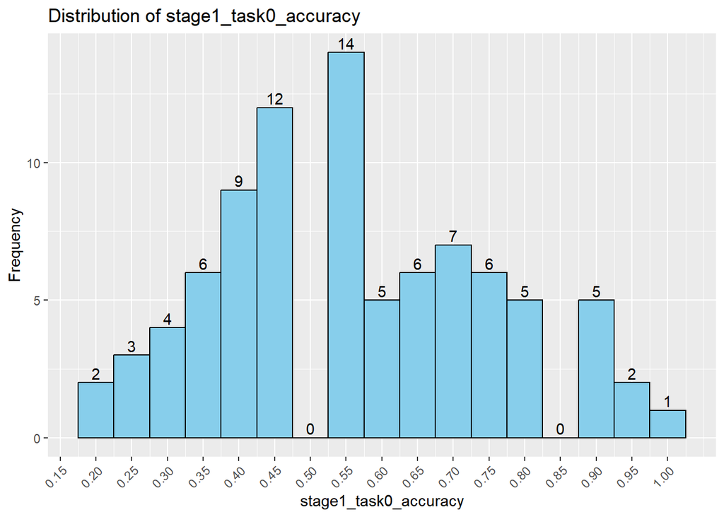

```r
# Check Distribution
ggplot(df, aes(x = stage1_task0_accuracy)) +
  geom_histogram(binwidth = 0.05, fill = "skyblue", color = "black") +
  stat_bin(binwidth = 0.05, geom = "text", aes(label = ..count..), vjust = -0.3) +
  scale_x_continuous(
    breaks = seq(0, 1, by = 0.05),
    labels = sprintf("%.2f", seq(0, 1, by = 0.05))
  ) +
  labs(
    title = "Distribution of stage1_task0_accuracy",
    x = "stage1_task0_accuracy",
    y = "Frequency"
  ) +
  theme(axis.text.x = element_text(angle = 45, hjust = 1))
```

```r
# Filter Out stage1_task0_accuracy >= 0.9
Count <- sum(df$stage1_task0_accuracy >= 0.9)
Count
```

```
## [1] 3
```

```r
df <- df %>%
  filter(stage1_task0_accuracy < 0.9)
```

```r
# Recode Background and LLM Usage
df$Stats_Background <- cut(
  as.numeric(as.character(df$Stats_Background)),
  breaks = c(1, 3, 5, 8),
  labels = c("Low", "Medium", "High"),
  right = TRUE,
  include.lowest = TRUE
)

df$Used_LLM_Frequency <- forcats::fct_collapse(
  as.character(df$Used_LLM_Frequency),
  Rarely = c("Never", "Less than once a month", "1–3 times per month"),
  Often  = c("Weekly", "Daily")
)

df$Used_LLM_Hours <- forcats::fct_collapse(
  as.character(df$Used_LLM_Hours),
  None = "0",
  Low  = c("1–5", "6–10"),
  High = c("11–20", ">20")
)
```

```r
summary(df$Label)
```

```
##       AI AI Human    Human
##       29       24       31
```

```r
# Convert To Longer Table
cols_to_long <- grep("^(Pre|Post|stage\\d+|follow)_", colnames(df), value = TRUE)

df_long <- df %>%
  pivot_longer(
    cols = all_of(cols_to_long),
    names_to = "fullvar",
    values_to = "Value"
  ) %>%
  mutate(
    Phase = str_extract(fullvar, "^(Pre|Post|stage\\d+|follow)"),
    tmp = str_remove(fullvar, "^(Pre|Post|stage\\d+|follow)_"),
    task = ifelse(str_detect(tmp, "^task\\d+"), str_extract(tmp, "^task\\d+"), NA),
    measure = ifelse(!is.na(task), str_remove(tmp, "^task\\d+_"), tmp),
    tmp = NULL,
    fullvar = NULL
  )

df_long$Phase <- factor(df_long$Phase, levels = c("follow", "Post", "stage3", "stage2", "stage1", "Pre"))
df_long$Task <- as.factor(df_long$task)

df_long <- df_long %>%
  dplyr::select(-task)

df_long$Label <- as.factor(df_long$Label)
df_long$ID <- as.factor(df_long$ID)

head(df_long)
```

```
## # A tibble: 6 × 21
##   Attention_Check ID    Label Gender Age   Identity      Field Stats_Background
##             <dbl> <fct> <fct> <chr>  <chr> <chr>         <chr> <fct>
## 1               1 4     Human Female 21–30 Master or PHD Other Low
## 2               1 4     Human Female 21–30 Master or PHD Other Low
## 3               1 4     Human Female 21–30 Master or PHD Other Low
## 4               1 4     Human Female 21–30 Master or PHD Other Low
## 5               1 4     Human Female 21–30 Master or PHD Other Low
## 6               1 4     Human Female 21–30 Master or PHD Other Low
## # ℹ 13 more variables: Used_LLM <dbl>, Used_LLM_Frequency <fct>,
## #   Used_LLM_Hours <fct>, Task_Difficulty <dbl>, Stats_Improvement <dbl>,
## #   Satisfaction <dbl>, Recalled_Label <chr>, Sign_Up <dbl>, drop <dbl>,
## #   Value <dbl>, Phase <fct>, measure <chr>, Task <fct>
```

## Baseline Equivalence Across Conditions

Before testing the hypotheses, we verify that the three labelling conditions did not differ at baseline on the seven pre-survey measures (objective and subjective AI literacy, AI trust, usefulness, affect, self-efficacy, and behavioural intention). Per-condition descriptive statistics are followed by one-way ANOVAs.

```r
# Descriptive statistics by condition
varnames <- rename_vars[1:7]

label_summary <- lapply(varnames, function(var) {
  df %>%
    group_by(Label) %>%
    summarise(
      Mean = round(mean(.data[[var]], na.rm = TRUE), 2),
      SD = round(sd(.data[[var]], na.rm = TRUE), 2),
      n = sum(!is.na(.data[[var]]))
    ) %>%
    mutate(Variable = var) %>%
    relocate(Variable)
})

label_summary_table <- bind_rows(label_summary)
label_summary_table
```

```
## # A tibble: 21 × 5
##    Variable                            Label     Mean    SD     n
##    <chr>                               <fct>    <dbl> <dbl> <int>
##  1 Pre_GLAT_Objective_AI_Literacy      AI        0.75  0.19    29
##  2 Pre_GLAT_Objective_AI_Literacy      AI Human  0.71  0.18    24
##  3 Pre_GLAT_Objective_AI_Literacy      Human     0.73  0.18    31
##  4 Pre_AILS_CCS_Subjective_AI_Literacy AI        3.82  0.55    29
##  5 Pre_AILS_CCS_Subjective_AI_Literacy AI Human  3.89  0.33    24
##  6 Pre_AILS_CCS_Subjective_AI_Literacy Human     3.94  0.49    31
##  7 Pre_AI_Trust                        AI        3.2   0.72    29
##  8 Pre_AI_Trust                        AI Human  3.46  0.58    24
##  9 Pre_AI_Trust                        Human     3.36  0.79    31
## 10 Pre_AI_Usefulness                   AI        4.19  0.6     29
## # ℹ 11 more rows
```

```r
# ANOVA By Label
anova_results <- lapply(varnames, function(var) {
  aov_res <- summary(aov(df[[var]] ~ df$Label))
  data.frame(
    Variable = var,
    F_value = round(aov_res[[1]][["F value"]][1], 2),
    p_value = round(aov_res[[1]][["Pr(>F)"]][1], 4)
  )
})

anova_results_table <- bind_rows(anova_results)
anova_results_table
```

```
##                              Variable F_value p_value
## 1      Pre_GLAT_Objective_AI_Literacy    0.28  0.7553
## 2 Pre_AILS_CCS_Subjective_AI_Literacy    0.46  0.6349
## 3                        Pre_AI_Trust    0.91  0.4059
## 4                   Pre_AI_Usefulness    0.31  0.7321
## 5                       Pre_AI_Affect    0.22  0.7993
## 6                Pre_AI_Self_Efficacy    0.39  0.6791
## 7            Pre_Behavioral_Intention    0.56  0.5738
```

## H1: Long-Term Task Performance (Accuracy)

H1 tests whether task accuracy is retained at follow-up. Linear mixed models compare accuracy across the four phases (Stage 1–3 and follow-up) by labelling condition, adjusting for the dropout covariates.

### Descriptive Statistics

```r
performance_long <- df_long %>%
  rename(Measure = measure) %>%
  filter(
    Measure == "accuracy",
    Task != "task0"
  )

head(performance_long)
```

```
## # A tibble: 6 × 21
##   Attention_Check ID    Label Gender Age   Identity      Field Stats_Background
##             <dbl> <fct> <fct> <chr>  <chr> <chr>         <chr> <fct>
## 1               1 4     Human Female 21–30 Master or PHD Other Low
## 2               1 4     Human Female 21–30 Master or PHD Other Low
## 3               1 4     Human Female 21–30 Master or PHD Other Low
## 4               1 4     Human Female 21–30 Master or PHD Other Low
## 5               1 4     Human Female 21–30 Master or PHD Other Low
## 6               1 4     Human Female 21–30 Master or PHD Other Low
## # ℹ 13 more variables: Used_LLM <dbl>, Used_LLM_Frequency <fct>,
## #   Used_LLM_Hours <fct>, Task_Difficulty <dbl>, Stats_Improvement <dbl>,
## #   Satisfaction <dbl>, Recalled_Label <chr>, Sign_Up <dbl>, drop <dbl>,
## #   Value <dbl>, Phase <fct>, Measure <chr>, Task <fct>
```

```r
performance_long$Label <- as.factor(performance_long$Label)
performance_long$Phase <- as.factor(performance_long$Phase)
performance_long$Task <- as.factor(performance_long$Task)

stage_summary <- performance_long %>%
  group_by(Phase, Label) %>%
  summarise(
    Mean = round(mean(Value, na.rm = TRUE), 2),
    SD = round(sd(Value, na.rm = TRUE), 2),
    N = n()
  )

head(stage_summary)
```

```
## # A tibble: 6 × 5
## # Groups:   Phase [2]
##   Phase  Label     Mean    SD     N
##   <fct>  <fct>    <dbl> <dbl> <int>
## 1 follow AI        0.63  0.3     87
## 2 follow AI Human  0.65  0.25    72
## 3 follow Human     0.62  0.27    93
## 4 stage3 AI        0.91  0.18    87
## 5 stage3 AI Human  0.91  0.15    72
## 6 stage3 Human     0.89  0.19    93
```

### Linear Mixed Models

Phase is the within-participant factor and Label the between-participant factor; results are reported without and with the task factor.

#### Without Task

```r
follow_up_stage <- c("stage1", "stage2", "stage3", "follow")

performance_long1 <- performance_long %>%
  filter(Phase %in% follow_up_stage)

performance_long1$Phase <- factor(performance_long1$Phase, levels = c("follow", "stage3", "stage2", "stage1"))

model <- lmer(
  Value ~ Phase * Label + Age + Gender + Field + Used_LLM_Hours +
    (1 | ID) + (1 | Task) + (1 | ID:Task),
  data = performance_long1
)

cat("===LMM MODEL SUM===\n")
```

```
## ===LMM MODEL SUM===
```

```r
model_summary <- summary(model)$coefficients
print(model_summary)
```

```
##                                          Estimate Std. Error        df
## (Intercept)                           0.619042255 0.10661615  23.12678
## Phasestage3                           0.283126437 0.03160575 747.00158
## Phasestage2                          -0.078931034 0.03160575 747.00157
## Phasestage1                          -0.093494253 0.03160575 747.00158
## LabelAI Human                         0.045026880 0.04664728 178.42083
## LabelHuman                            0.025267964 0.04315600 183.28256
## Age21–30                             -0.076918390 0.06184338  70.99868
## Age31–40                              0.035099346 0.14079604  70.99868
## GenderMale                           -0.073304648 0.03048055  70.99868
## GenderPrefer not to say              -0.211549568 0.13268172  70.99868
## FieldComputer Science or Engineering  0.125636702 0.06337253  70.99868
## FieldHealth and Medical               0.025551379 0.07557505  70.99868
## FieldNatural Sciences                -0.031722575 0.13461647  70.99868
## FieldOther                           -0.127488603 0.13721552  70.99868
## FieldSocial Sciences                  0.122456519 0.06446633  70.99868
## Used_LLM_HoursLow                    -0.017932695 0.03130872  70.99868
## Phasestage3:LabelAI Human            -0.018793103 0.04696760 747.00158
## Phasestage2:LabelAI Human             0.083542146 0.04696760 747.00158
## Phasestage1:LabelAI Human            -0.006950192 0.04696760 747.00158
## Phasestage3:LabelHuman               -0.010008157 0.04397044 747.00158
## Phasestage2:LabelHuman                0.039565443 0.04397044 747.00158
## Phasestage1:LabelHuman                0.011128661 0.04397044 747.00158
##                                         t value     Pr(>|t|)
## (Intercept)                           5.8062708 6.331550e-06
## Phasestage3                           8.9580682 2.600137e-18
## Phasestage2                          -2.4973634 1.272620e-02
## Phasestage1                          -2.9581409 3.192723e-03
## LabelAI Human                         0.9652627 3.357197e-01
## LabelHuman                            0.5855030 5.589298e-01
## Age21–30                             -1.2437612 2.176785e-01
## Age31–40                              0.2492921 8.038546e-01
## GenderMale                           -2.4049651 1.878345e-02
## GenderPrefer not to say              -1.5944138 1.152857e-01
## FieldComputer Science or Engineering  1.9825105 5.129265e-02
## FieldHealth and Medical               0.3380928 7.362910e-01
## FieldNatural Sciences                -0.2356515 8.143815e-01
## FieldOther                           -0.9291121 3.559792e-01
## FieldSocial Sciences                  1.8995423 6.155556e-02
## Used_LLM_HoursLow                    -0.5727699 5.686100e-01
## Phasestage3:LabelAI Human            -0.4001291 6.891758e-01
## Phasestage2:LabelAI Human             1.7787186 7.569251e-02
## Phasestage1:LabelAI Human            -0.1479784 8.823997e-01
## Phasestage3:LabelHuman               -0.2276110 8.200109e-01
## Phasestage2:LabelHuman                0.8998191 3.685065e-01
## Phasestage1:LabelHuman                0.2530941 8.002651e-01
```

```r
anova_results <- anova(model)
cat("\n===ANOVA===\n")
```

```
##
## ===ANOVA===
```

```r
print(anova_results)
```

```
## Type III Analysis of Variance Table with Satterthwaite's method
##                 Sum Sq Mean Sq NumDF DenDF  F value  Pr(>F)
## Phase          19.8215  6.6072     3   747 152.0524 < 2e-16 ***
## Label           0.1208  0.0604     2    71   1.3900 0.25578
## Age             0.0958  0.0479     2    71   1.1029 0.33754
## Gender          0.3300  0.1650     2    71   3.7976 0.02711 *
## Field           0.4858  0.0972     5    71   2.2360 0.05997 .
## Used_LLM_Hours  0.0143  0.0143     1    71   0.3281 0.56861
## Phase:Label     0.2670  0.0445     6   747   1.0243 0.40803
## ---
## Signif. codes:  0 '***' 0.001 '**' 0.01 '*' 0.05 '.' 0.1 ' ' 1
```

```r
eta_sq <- effectsize::eta_squared(model, partial = TRUE)
cat("\n===ETA SQUARED===\n")
```

```
##
## ===ETA SQUARED===
```

```r
print(eta_sq)
```

```
## # Effect Size for ANOVA (Type III)
##
## Parameter      | Eta2 (partial) |       95% CI
## ----------------------------------------------
## Phase          |           0.38 | [0.34, 1.00]
## Label          |           0.04 | [0.00, 1.00]
## Age            |           0.03 | [0.00, 1.00]
## Gender         |           0.10 | [0.01, 1.00]
## Field          |           0.14 | [0.00, 1.00]
## Used_LLM_Hours |       4.60e-03 | [0.00, 1.00]
## Phase:Label    |       8.16e-03 | [0.00, 1.00]
##
## - One-sided CIs: upper bound fixed at [1.00].
```

```r
posthoc_stage <- emmeans(model, pairwise ~ Phase)
cat("\n===POST HOC STAGE===\n")
```

```
##
## ===POST HOC STAGE===
```

```r
print(posthoc_stage$contrasts)
```

```
##  contrast        estimate     SE  df t.ratio p.value
##  follow - stage3  -0.2735 0.0187 747 -14.643  <.0001
##  follow - stage2   0.0379 0.0187 747   2.029  0.1783
##  follow - stage1   0.0921 0.0187 747   4.931  <.0001
##  stage3 - stage2   0.3114 0.0187 747  16.672  <.0001
##  stage3 - stage1   0.3656 0.0187 747  19.573  <.0001
##  stage2 - stage1   0.0542 0.0187 747   2.902  0.0199
##
## Results are averaged over the levels of: Label, Age, Gender, Field, Used_LLM_Hours
## Degrees-of-freedom method: kenward-roger
## P value adjustment: tukey method for comparing a family of 4 estimates
```

```r
posthoc_label <- emmeans(model, pairwise ~ Label)
cat("\n===POST HOC LABEL===\n")
```

```
##
## ===POST HOC LABEL===
```

```r
print(posthoc_label$contrasts)
```

```
##  contrast         estimate     SE df t.ratio p.value
##  AI - AI Human     -0.0595 0.0367 71  -1.620  0.2441
##  AI - Human        -0.0354 0.0337 71  -1.051  0.5476
##  AI Human - Human   0.0240 0.0378 71   0.636  0.8006
##
## Results are averaged over the levels of: Phase, Age, Gender, Field, Used_LLM_Hours
## Degrees-of-freedom method: kenward-roger
## P value adjustment: tukey method for comparing a family of 3 estimates
```

```r
posthoc_stage_label <- emmeans(model, pairwise ~ Phase | Label)
cat("\n===POST HOC PHASE X LABEL===\n")
```

```
##
## ===POST HOC PHASE X LABEL===
```

```r
print(posthoc_stage_label$contrasts)
```

```
## Label = AI:
##  contrast        estimate     SE  df t.ratio p.value
##  follow - stage3 -0.28313 0.0316 747  -8.958  <.0001
##  follow - stage2  0.07893 0.0316 747   2.497  0.0611
##  follow - stage1  0.09349 0.0316 747   2.958  0.0168
##  stage3 - stage2  0.36206 0.0316 747  11.455  <.0001
##  stage3 - stage1  0.37662 0.0316 747  11.916  <.0001
##  stage2 - stage1  0.01456 0.0316 747   0.461  0.9675
##
## Label = AI Human:
##  contrast        estimate     SE  df t.ratio p.value
##  follow - stage3 -0.26433 0.0347 747  -7.608  <.0001
##  follow - stage2 -0.00461 0.0347 747  -0.133  0.9992
##  follow - stage1  0.10044 0.0347 747   2.891  0.0206
##  stage3 - stage2  0.25972 0.0347 747   7.476  <.0001
##  stage3 - stage1  0.36478 0.0347 747  10.500  <.0001
##  stage2 - stage1  0.10506 0.0347 747   3.024  0.0137
##
## Label = Human:
##  contrast        estimate     SE  df t.ratio p.value
##  follow - stage3 -0.27312 0.0306 747  -8.934  <.0001
##  follow - stage2  0.03937 0.0306 747   1.288  0.5710
##  follow - stage1  0.08237 0.0306 747   2.694  0.0362
##  stage3 - stage2  0.31248 0.0306 747  10.222  <.0001
##  stage3 - stage1  0.35548 0.0306 747  11.629  <.0001
##  stage2 - stage1  0.04300 0.0306 747   1.407  0.4955
##
## Results are averaged over the levels of: Age, Gender, Field, Used_LLM_Hours
## Degrees-of-freedom method: kenward-roger
## P value adjustment: tukey method for comparing a family of 4 estimates
```

```r
posthoc_label_stage <- emmeans(model, pairwise ~ Label | Phase)
cat("\n===POST HOC LABEL X PHASE===\n")
```

```
##
## ===POST HOC LABEL X PHASE===
```

```r
print(posthoc_label_stage$contrasts)
```

```
## Phase = follow:
##  contrast         estimate     SE  df t.ratio p.value
##  AI - AI Human    -0.04503 0.0466 178  -0.965  0.5998
##  AI - Human       -0.02527 0.0432 183  -0.586  0.8281
##  AI Human - Human  0.01976 0.0472 168   0.418  0.9081
##
## Phase = stage3:
##  contrast         estimate     SE  df t.ratio p.value
##  AI - AI Human    -0.02623 0.0466 178  -0.562  0.8402
##  AI - Human       -0.01526 0.0432 183  -0.354  0.9334
##  AI Human - Human  0.01097 0.0472 168   0.232  0.9707
##
## Phase = stage2:
##  contrast         estimate     SE  df t.ratio p.value
##  AI - AI Human    -0.12857 0.0466 178  -2.756  0.0177
##  AI - Human       -0.06483 0.0432 183  -1.502  0.2922
##  AI Human - Human  0.06374 0.0472 168   1.350  0.3699
##
## Phase = stage1:
##  contrast         estimate     SE  df t.ratio p.value
##  AI - AI Human    -0.03808 0.0466 178  -0.816  0.6934
##  AI - Human       -0.03640 0.0432 183  -0.843  0.6766
##  AI Human - Human  0.00168 0.0472 168   0.036  0.9993
##
## Results are averaged over the levels of: Age, Gender, Field, Used_LLM_Hours
## Degrees-of-freedom method: kenward-roger
## P value adjustment: tukey method for comparing a family of 3 estimates
```

```r
write.xlsx(
  list(
    Model_Summary = as.data.frame(model_summary),
    ANOVA = as.data.frame(anova_results),
    Eta_Squared = as.data.frame(eta_sq),
    Posthoc_Stage = as.data.frame(posthoc_stage$contrasts),
    Posthoc_Label = as.data.frame(posthoc_label$contrasts),
    Posthoc_Stage_Label = as.data.frame(posthoc_stage_label$contrasts)
  ),
  file = "results/Follow-Up Activity/H1/H1_Stage1_Longterm_Accuracy_Comparison_LMM.xlsx",
  rowNames = TRUE
)
```

#### With Task

```r
follow_up_stage <- c("stage1", "stage2", "stage3", "follow")

performance_long1 <- performance_long %>%
  filter(Phase %in% follow_up_stage)

performance_long1$Phase <- factor(performance_long1$Phase, levels = c("follow", "stage3", "stage2", "stage1"))

model <- lmer(
  Value ~ Phase * Label * Task + Age + Gender + Field + Used_LLM_Hours +
    (1 | ID) + (1 | ID:Task),
  data = performance_long1
)

cat("===LMM MODEL SUM===\n")
```

```
## ===LMM MODEL SUM===
```

```r
model_summary <- summary(model)$coefficients

anova_results <- anova(model)
cat("\n===ANOVA===\n")
```

```
##
## ===ANOVA===
```

```r
print(anova_results)
```

```
## Type III Analysis of Variance Table with Satterthwaite's method
##                   Sum Sq Mean Sq NumDF DenDF  F value    Pr(>F)
## Phase            19.8215  6.6072     3   729 156.8970 < 2.2e-16 ***
## Label             0.1171  0.0585     2    71   1.3900   0.25577
## Task              3.5927  1.7963     2   162  42.6570 1.311e-15 ***
## Age               0.0929  0.0464     2    71   1.1029   0.33753
## Gender            0.3198  0.1599     2    71   3.7976   0.02711 *
## Field             0.4708  0.0942     5    71   2.2361   0.05997 .
## Used_LLM_Hours    0.0138  0.0138     1    71   0.3281   0.56861
## Phase:Label       0.2670  0.0445     6   729   1.0569   0.38711
## Phase:Task        1.3771  0.2295     6   729   5.4502 1.578e-05 ***
## Label:Task        0.1258  0.0314     4   162   0.7467   0.56158
## Phase:Label:Task  0.3455  0.0288    12   729   0.6837   0.76820
## ---
## Signif. codes:  0 '***' 0.001 '**' 0.01 '*' 0.05 '.' 0.1 ' ' 1
```

```r
eta_sq <- effectsize::eta_squared(model, partial = TRUE)
cat("\n===ETA SQUARED===\n")
```

```
##
## ===ETA SQUARED===
```

```r
print(eta_sq)
```

```
## # Effect Size for ANOVA (Type III)
##
## Parameter        | Eta2 (partial) |       95% CI
## ------------------------------------------------
## Phase            |           0.39 | [0.35, 1.00]
## Label            |           0.04 | [0.00, 1.00]
## Task             |           0.34 | [0.25, 1.00]
## Age              |           0.03 | [0.00, 1.00]
## Gender           |           0.10 | [0.01, 1.00]
## Field            |           0.14 | [0.00, 1.00]
## Used_LLM_Hours   |       4.60e-03 | [0.00, 1.00]
## Phase:Label      |       8.62e-03 | [0.00, 1.00]
## Phase:Task       |           0.04 | [0.02, 1.00]
## Label:Task       |           0.02 | [0.00, 1.00]
## Phase:Label:Task |           0.01 | [0.00, 1.00]
##
## - One-sided CIs: upper bound fixed at [1.00].
```

```r
posthoc_stage <- emmeans(model, pairwise ~ Phase)
cat("\n===POST HOC STAGE===\n")
```

```
##
## ===POST HOC STAGE===
```

```r
print(posthoc_stage$contrasts)
```

```
##  contrast        estimate     SE  df t.ratio p.value
##  follow - stage3  -0.2735 0.0184 729 -14.874  <.0001
##  follow - stage2   0.0379 0.0184 729   2.061  0.1671
##  follow - stage1   0.0921 0.0184 729   5.008  <.0001
##  stage3 - stage2   0.3114 0.0184 729  16.935  <.0001
##  stage3 - stage1   0.3656 0.0184 729  19.883  <.0001
##  stage2 - stage1   0.0542 0.0184 729   2.948  0.0174
##
## Results are averaged over the levels of: Label, Task, Age, Gender, Field, Used_LLM_Hours
## Degrees-of-freedom method: kenward-roger
## P value adjustment: tukey method for comparing a family of 4 estimates
```

```r
posthoc_label <- emmeans(model, pairwise ~ Task)
cat("\n===POST HOC Task===\n")
```

```
##
## ===POST HOC Task===
```

```r
print(posthoc_label$contrasts)
```

```
##  contrast      estimate     SE  df t.ratio p.value
##  task1 - task2   0.0845 0.0206 162   4.104  0.0002
##  task1 - task3  -0.1053 0.0206 162  -5.114  <.0001
##  task2 - task3  -0.1897 0.0206 162  -9.218  <.0001
##
## Results are averaged over the levels of: Phase, Label, Age, Gender, Field, Used_LLM_Hours
## Degrees-of-freedom method: kenward-roger
## P value adjustment: tukey method for comparing a family of 3 estimates
```

```r
posthoc_stage_label <- emmeans(model, pairwise ~ Phase | Task)
cat("\n===POST HOC PHASE X Task===\n")
```

```
##
## ===POST HOC PHASE X Task===
```

```r
print(posthoc_stage_label$contrasts)
```

```
## Task = task1:
##  contrast        estimate     SE  df t.ratio p.value
##  follow - stage3  -0.3077 0.0319 729  -9.660  <.0001
##  follow - stage2   0.0702 0.0319 729   2.203  0.1234
##  follow - stage1   0.1121 0.0319 729   3.518  0.0026
##  stage3 - stage2   0.3779 0.0319 729  11.863  <.0001
##  stage3 - stage1   0.4197 0.0319 729  13.178  <.0001
##  stage2 - stage1   0.0419 0.0319 729   1.315  0.5535
##
## Task = task2:
##  contrast        estimate     SE  df t.ratio p.value
##  follow - stage3  -0.3137 0.0319 729  -9.850  <.0001
##  follow - stage2   0.0614 0.0319 729   1.928  0.2170
##  follow - stage1   0.1232 0.0319 729   3.867  0.0007
##  stage3 - stage2   0.3751 0.0319 729  11.778  <.0001
##  stage3 - stage1   0.4369 0.0319 729  13.716  <.0001
##  stage2 - stage1   0.0617 0.0319 729   1.938  0.2130
##
## Task = task3:
##  contrast        estimate     SE  df t.ratio p.value
##  follow - stage3  -0.1992 0.0319 729  -6.253  <.0001
##  follow - stage2  -0.0179 0.0319 729  -0.562  0.9432
##  follow - stage1   0.0411 0.0319 729   1.290  0.5696
##  stage3 - stage2   0.1813 0.0319 729   5.691  <.0001
##  stage3 - stage1   0.2403 0.0319 729   7.543  <.0001
##  stage2 - stage1   0.0590 0.0319 729   1.852  0.2499
##
## Results are averaged over the levels of: Label, Age, Gender, Field, Used_LLM_Hours
## Degrees-of-freedom method: kenward-roger
## P value adjustment: tukey method for comparing a family of 4 estimates
```

```r
posthoc_stage_task_label <- emmeans(model, pairwise ~ Phase | Task | Label)
cat("\n===POST HOC PHASE X Task X Label===\n")
```

```
##
## ===POST HOC PHASE X Task X Label===
```

```r
print(posthoc_stage_task_label$contrasts)
```

```
## Task = task1, Label = AI:
##  contrast        estimate     SE  df t.ratio p.value
##  follow - stage3 -0.32183 0.0539 729  -5.972  <.0001
##  follow - stage2  0.07466 0.0539 729   1.385  0.5090
##  follow - stage1  0.06317 0.0539 729   1.172  0.6446
##  stage3 - stage2  0.39648 0.0539 729   7.357  <.0001
##  stage3 - stage1  0.38500 0.0539 729   7.144  <.0001
##  stage2 - stage1 -0.01148 0.0539 729  -0.213  0.9966
##
## Task = task2, Label = AI:
##  contrast        estimate     SE  df t.ratio p.value
##  follow - stage3 -0.33793 0.0539 729  -6.271  <.0001
##  follow - stage2  0.11034 0.0539 729   2.048  0.1717
##  follow - stage1  0.13103 0.0539 729   2.431  0.0722
##  stage3 - stage2  0.44828 0.0539 729   8.318  <.0001
##  stage3 - stage1  0.46897 0.0539 729   8.702  <.0001
##  stage2 - stage1  0.02069 0.0539 729   0.384  0.9807
##
## Task = task3, Label = AI:
##  contrast        estimate     SE  df t.ratio p.value
##  follow - stage3 -0.18962 0.0539 729  -3.519  0.0026
##  follow - stage2  0.05179 0.0539 729   0.961  0.7716
##  follow - stage1  0.08628 0.0539 729   1.601  0.3787
##  stage3 - stage2  0.24141 0.0539 729   4.480  0.0001
##  stage3 - stage1  0.27590 0.0539 729   5.120  <.0001
##  stage2 - stage1  0.03448 0.0539 729   0.640  0.9191
##
## Task = task1, Label = AI Human:
##  contrast        estimate     SE  df t.ratio p.value
##  follow - stage3 -0.30558 0.0592 729  -5.158  <.0001
##  follow - stage2  0.00688 0.0592 729   0.116  0.9994
##  follow - stage1  0.09029 0.0592 729   1.524  0.4235
##  stage3 - stage2  0.31246 0.0592 729   5.275  <.0001
##  stage3 - stage1  0.39587 0.0592 729   6.683  <.0001
##  stage2 - stage1  0.08342 0.0592 729   1.408  0.4946
##
## Task = task2, Label = AI Human:
##  contrast        estimate     SE  df t.ratio p.value
##  follow - stage3 -0.30000 0.0592 729  -5.064  <.0001
##  follow - stage2  0.04167 0.0592 729   0.703  0.8958
```

[output cut: 29 more lines]

```
##  stage3 - stage1  0.40000 0.0521 729   7.674  <.0001
##  stage2 - stage1  0.06452 0.0521 729   1.238  0.6030
##
## Task = task3, Label = Human:
##  contrast        estimate     SE  df t.ratio p.value
##  follow - stage3 -0.22048 0.0521 729  -4.230  0.0002
##  follow - stage2 -0.04313 0.0521 729  -0.827  0.8415
##  follow - stage1 -0.03239 0.0521 729  -0.621  0.9252
##  stage3 - stage2  0.17735 0.0521 729   3.403  0.0039
##  stage3 - stage1  0.18810 0.0521 729   3.609  0.0019
##  stage2 - stage1  0.01074 0.0521 729   0.206  0.9969
##
## Results are averaged over the levels of: Age, Gender, Field, Used_LLM_Hours
## Degrees-of-freedom method: kenward-roger
## P value adjustment: tukey method for comparing a family of 4 estimates
```

### Robustness: Item-Level Binomial GLMM

The H1 models treat phase-level accuracy — a proportion of only 5–6 binary items — as a Gaussian outcome, which can strain linear-model assumptions. As a robustness check we refit the phase effect as an **item-level binomial GLMM** (the response family used for the early/late analysis), modelling each binary item response directly with the same fixed effects and covariates and crossed participant, item, and task intercepts:

`correct ~ Phase * Label + Age + Gender + Field + Used_LLM_Hours + (1 | ID) + (1 | Item) + (1 | Task)`

Item responses are read from `correction_raw_data.xlsx` for the same cohort as the H1 model (follow-up completers passing the ceiling screen). With only three task levels the `(1 | Task)` variance may sit near the boundary, but this does not affect the Phase × Label inference. Matching the Gaussian LMM confirms the conclusion is robust to the modelling choice.

#### Build Item-Level Dataset (Follow-Up Completer Cohort)

```r
# Ground-truth key for the 17 items (task 1: 6, task 2: 5, task 3: 6).
item_names <- c(paste0("t1_q", 1:6), paste0("t2_q", 1:5), paste0("t3_q", 1:6))
item_truth <- c(rep(FALSE, 6), rep(FALSE, 5), FALSE, TRUE, TRUE, TRUE, FALSE, TRUE)
names(item_truth) <- item_names

# Analytic cohort = the same follow-up completers used by the H1 model.
cohort_ids <- unique(as.character(df$ID))

# Per-participant covariates, recoded identically to the primary model.
demo <- df %>%
  mutate(ID = as.character(ID)) %>%
  dplyr::select(ID, Label, Age, Gender, Field, Used_LLM_Hours) %>%
  distinct()

# Item columns span the three learning stages plus the follow-up phase.
stage_cols  <- paste0(rep(c("stage1_", "stage2_", "stage3_"), each = length(item_names)), item_names)
follow_cols <- paste0("follow_up_", item_names)

item_long <- read_excel("data/correction_raw_data.xlsx") %>%
  mutate(ID = as.character(ID)) %>%
  filter(ID %in% cohort_ids) %>%
  dplyr::select(ID, all_of(stage_cols), all_of(follow_cols)) %>%
  pivot_longer(
    cols = c(all_of(stage_cols), all_of(follow_cols)),
    names_to = c("Phase", "Item"),
    names_pattern = "^(stage[123]|follow_up)_(t[123]_q\\d+)$",
    values_to = "Answer"
  ) %>%
  mutate(
    Phase = ifelse(Phase == "follow_up", "follow", Phase),
    Truth = item_truth[as.character(Item)],
    correct = as.integer(as.logical(Answer) == Truth),
    Task = factor(sub("_q\\d+$", "", Item), levels = c("t1", "t2", "t3")),
    Item = factor(Item, levels = item_names),
    # Match the primary model's factor ordering (reference = follow).
    Phase = factor(Phase, levels = c("follow", "stage3", "stage2", "stage1")),
    ID = as.character(ID)
  ) %>%
  filter(!is.na(correct)) %>%
  left_join(demo, by = "ID") %>%
  mutate(ID = factor(ID))

# Cohort check: should equal the H1 analytic n across all four phases.
cat("Item-level cohort n =", dplyr::n_distinct(item_long$ID),
    "| item responses =", nrow(item_long), "\n")
```

```
## Item-level cohort n = 84 | item responses = 5712
```

```r
print(item_long %>% group_by(Phase) %>% summarise(n_resp = dplyr::n(), n_id = dplyr::n_distinct(ID)))
```

```
## # A tibble: 4 × 3
##   Phase  n_resp  n_id
##   <fct>   <int> <int>
## 1 follow   1428    84
## 2 stage3   1428    84
## 3 stage2   1428    84
## 4 stage1   1428    84
```

```r
head(item_long)
```

```
## # A tibble: 6 × 12
##   ID    Phase  Item  Answer Truth correct Task  Label Age   Gender Field
##   <fct> <fct>  <fct> <lgl>  <lgl>   <int> <fct> <fct> <chr> <chr>  <chr>
## 1 4     stage1 t1_q1 TRUE   FALSE       0 t1    Human 21–30 Female Other
## 2 4     stage1 t1_q2 TRUE   FALSE       0 t1    Human 21–30 Female Other
## 3 4     stage1 t1_q3 TRUE   FALSE       0 t1    Human 21–30 Female Other
## 4 4     stage1 t1_q4 TRUE   FALSE       0 t1    Human 21–30 Female Other
## 5 4     stage1 t1_q5 TRUE   FALSE       0 t1    Human 21–30 Female Other
## 6 4     stage1 t1_q6 FALSE  FALSE       1 t1    Human 21–30 Female Other
## # ℹ 1 more variable: Used_LLM_Hours <fct>
```

#### Fit Item-Level Binomial GLMM

```r
itemlevel_model <- glmer(
  correct ~ Phase * Label + Age + Gender + Field + Used_LLM_Hours +
    (1 | ID) + (1 | Item) + (1 | Task),
  data = item_long,
  family = binomial,
  control = glmerControl(optimizer = "bobyqa", optCtrl = list(maxfun = 2e5))
)

summary(itemlevel_model)
```

```
## Generalized linear mixed model fit by maximum likelihood (Laplace
##   Approximation) [glmerMod]
##  Family: binomial  ( logit )
## Formula: correct ~ Phase * Label + Age + Gender + Field + Used_LLM_Hours +
##     (1 | ID) + (1 | Item) + (1 | Task)
##    Data: item_long
## Control: glmerControl(optimizer = "bobyqa", optCtrl = list(maxfun = 2e+05))
##
##       AIC       BIC    logLik -2*log(L)  df.resid
##    5989.6    6155.9   -2969.8    5939.6      5687
##
## Scaled residuals:
##      Min       1Q   Median       3Q      Max
## -14.9733  -0.7516   0.3146   0.6295   3.2836
##
## Random effects:
##  Groups Name        Variance Std.Dev.
##  ID     (Intercept) 0.3461   0.5883
##  Item   (Intercept) 0.3926   0.6266
##  Task   (Intercept) 0.1618   0.4023
## Number of obs: 5712, groups:  ID, 84; Item, 17; Task, 3
##
## Fixed effects:
##                                      Estimate Std. Error z value Pr(>|z|)
## (Intercept)                           0.56462    0.56315   1.003  0.31605
## Phasestage3                           2.08188    0.19797  10.516  < 2e-16 ***
## Phasestage2                          -0.38712    0.14281  -2.711  0.00671 **
## Phasestage1                          -0.45671    0.14270  -3.200  0.00137 **
## LabelAI Human                         0.23133    0.23634   0.979  0.32767
## LabelHuman                            0.14701    0.21807   0.674  0.50023
## Age21–30                             -0.46955    0.33582  -1.398  0.16205
## Age31–40                              0.37443    0.79651   0.470  0.63829
## GenderMale                           -0.45261    0.16532  -2.738  0.00618 **
## GenderPrefer not to say              -1.23045    0.70850  -1.737  0.08244 .
## FieldComputer Science or Engineering  0.78970    0.33996   2.323  0.02018 *
## FieldHealth and Medical               0.15653    0.40419   0.387  0.69857
## FieldNatural Sciences                -0.16451    0.71620  -0.230  0.81832
## FieldOther                           -0.53464    0.73052  -0.732  0.46425
## FieldSocial Sciences                  0.76944    0.34520   2.229  0.02581 *
## Used_LLM_HoursLow                    -0.06635    0.16916  -0.392  0.69490
## Phasestage3:LabelAI Human            -0.08650    0.29405  -0.294  0.76863
## Phasestage2:LabelAI Human             0.42581    0.21456   1.985  0.04719 *
## Phasestage1:LabelAI Human            -0.03454    0.21210  -0.163  0.87064
## Phasestage3:LabelHuman               -0.17860    0.26713  -0.669  0.50375
## Phasestage2:LabelHuman                0.18619    0.19863   0.937  0.34855
## Phasestage1:LabelHuman                0.05028    0.19814   0.254  0.79967
## ---
## Signif. codes:  0 '***' 0.001 '**' 0.01 '*' 0.05 '.' 0.1 ' ' 1
```

#### Odds Ratios, Type-III Tests, and Contrasts

```r
# Odds ratios for fixed effects (Wald CIs).
itemlevel_or <- exp(cbind(
  OR = fixef(itemlevel_model),
  confint(itemlevel_model, parm = "beta_", method = "Wald")
))
itemlevel_or
```

```
##                                             OR      2.5 %     97.5 %
## (Intercept)                          1.7587869 0.58325103  5.3036018
## Phasestage3                          8.0195121 5.44042223 11.8212470
## Phasestage2                          0.6790069 0.51323119  0.8983287
## Phasestage1                          0.6333644 0.47883464  0.8377641
## LabelAI Human                        1.2602798 0.79303435  2.0028203
## LabelHuman                           1.1583627 0.75548167  1.7760908
## Age21–30                             0.6252837 0.32376254  1.2076124
## Age31–40                             1.4541627 0.30522773  6.9279061
## GenderMale                           0.6359689 0.45995921  0.8793310
## GenderPrefer not to say              0.2921598 0.07286939  1.1713746
## FieldComputer Science or Engineering 2.2027444 1.13134140  4.2887874
## FieldHealth and Medical              1.1694427 0.52957659  2.5824331
## FieldNatural Sciences                0.8483085 0.20841389  3.4528761
## FieldOther                           0.5858786 0.13995611  2.4525815
## FieldSocial Sciences                 2.1585673 1.09731500  4.2461943
## Used_LLM_HoursLow                    0.9358067 0.67173699  1.3036861
## Phasestage3:LabelAI Human            0.9171376 0.51539655  1.6320277
## Phasestage2:LabelAI Human            1.5308233 1.00528905  2.3310908
## Phasestage1:LabelAI Human            0.9660514 0.63747278  1.4639925
## Phasestage3:LabelHuman               0.8364374 0.49550713  1.4119424
## Phasestage2:LabelHuman               1.2046533 0.81619094  1.7780026
## Phasestage1:LabelHuman               1.0515696 0.71314578  1.5505926
```

```r
# Type-III tests (matches the early/late analysis convention).
itemlevel_anova <- car::Anova(itemlevel_model, type = 3)
itemlevel_anova
```

```
## Analysis of Deviance Table (Type III Wald chisquare tests)
##
## Response: correct
##                   Chisq Df Pr(>Chisq)
## (Intercept)      1.0052  1   0.316049
## Phase          184.6404  3  < 2.2e-16 ***
## Label            1.0312  2   0.597135
## Age              3.1390  2   0.208149
## Gender           9.6011  2   0.008225 **
## Field           13.7784  5   0.017080 *
## Used_LLM_Hours   0.1538  1   0.694898
## Phase:Label      7.2577  6   0.297670
## ---
## Signif. codes:  0 '***' 0.001 '**' 0.01 '*' 0.05 '.' 0.1 ' ' 1
```

```r
# Phase contrasts overall and within each label, on the response scale.
itemlevel_emm_phase <- emmeans(itemlevel_model, pairwise ~ Phase, type = "response")
itemlevel_emm_phase_label <- emmeans(itemlevel_model, pairwise ~ Phase | Label, type = "response")
itemlevel_emm_phase$contrasts
```

```
##  contrast        odds.ratio     SE  df null z.ratio p.value
##  follow / stage3      0.136 0.0158 Inf    1 -17.160  <.0001
##  follow / stage2      1.201 0.1020 Inf    1   2.153  0.1366
##  follow / stage1      1.571 0.1330 Inf    1   5.351  <.0001
##  stage3 / stage2      8.817 1.0200 Inf    1  18.733  <.0001
##  stage3 / stage1     11.530 1.3400 Inf    1  21.046  <.0001
##  stage2 / stage1      1.308 0.1100 Inf    1   3.201  0.0075
##
## Results are averaged over the levels of: Label, Age, Gender, Field, Used_LLM_Hours
## P value adjustment: tukey method for comparing a family of 4 estimates
## Tests are performed on the log odds ratio scale
```

```r
itemlevel_emm_phase_label$contrasts
```

```
## Label = AI:
##  contrast        odds.ratio     SE  df null z.ratio p.value
##  follow / stage3      0.125 0.0247 Inf    1 -10.516  <.0001
##  follow / stage2      1.473 0.2100 Inf    1   2.711  0.0339
##  follow / stage1      1.579 0.2250 Inf    1   3.200  0.0075
##  stage3 / stage2     11.811 2.3300 Inf    1  12.508  <.0001
##  stage3 / stage1     12.662 2.5000 Inf    1  12.858  <.0001
##  stage2 / stage1      1.072 0.1510 Inf    1   0.495  0.9603
##
## Label = AI Human:
##  contrast        odds.ratio     SE  df null z.ratio p.value
##  follow / stage3      0.136 0.0297 Inf    1  -9.122  <.0001
##  follow / stage2      0.962 0.1540 Inf    1  -0.242  0.9950
##  follow / stage1      1.634 0.2570 Inf    1   3.128  0.0095
##  stage3 / stage2      7.076 1.5500 Inf    1   8.937  <.0001
##  stage3 / stage1     12.021 2.6100 Inf    1  11.432  <.0001
##  stage2 / stage1      1.699 0.2670 Inf    1   3.366  0.0042
##
## Label = Human:
##  contrast        odds.ratio     SE  df null z.ratio p.value
##  follow / stage3      0.149 0.0270 Inf    1 -10.519  <.0001
##  follow / stage2      1.223 0.1690 Inf    1   1.455  0.4650
##  follow / stage1      1.501 0.2070 Inf    1   2.954  0.0166
##  stage3 / stage2      8.201 1.4800 Inf    1  11.656  <.0001
##  stage3 / stage1     10.071 1.8200 Inf    1  12.797  <.0001
##  stage2 / stage1      1.228 0.1680 Inf    1   1.506  0.4340
##
## Results are averaged over the levels of: Age, Gender, Field, Used_LLM_Hours
## P value adjustment: tukey method for comparing a family of 4 estimates
## Tests are performed on the log odds ratio scale
```

#### Export Item-Level Robustness Results

```r
write.xlsx(
  list(
    Fixed_Effects = as.data.frame(summary(itemlevel_model)$coefficients),
    Odds_Ratios = as.data.frame(itemlevel_or),
    Type3_ANOVA = as.data.frame(itemlevel_anova),
    Posthoc_Phase = as.data.frame(itemlevel_emm_phase$contrasts),
    Posthoc_Phase_by_Label = as.data.frame(itemlevel_emm_phase_label$contrasts)
  ),
  file = "results/Follow-Up Activity/H1/H1_Performance_ItemLevel_Binomial_GLMM.xlsx",
  rowNames = TRUE
)
```

### H1 Sensitivity: Manipulation Passers Only

Because source attribution is the manipulation, we refit the primary H1 model (without the task factor) on participants who correctly recalled their assigned label. Recall (`Recalled_Label`) is taken from this analysis’s data file, where every participant in the cohort has a response. If the Phase × Label pattern holds, the conclusion is not driven by participants who misremembered their condition.

#### Restrict to Passers

```r
# Recall lookup from the analysis data file, recoded to match the Label factor
# ("AI", "AI Human", "Human").
recall_lk <- df %>%
  transmute(
    ID = as.character(ID),
    Recalled_Label = dplyr::recode(Recalled_Label, "AI + Human" = "AI Human")
  )

# Passer = recalled label matches assigned label.
passer_ids <- df %>%
  mutate(ID = as.character(ID)) %>%
  dplyr::select(ID, Label) %>%
  left_join(recall_lk, by = "ID") %>%
  filter(as.character(Label) == as.character(Recalled_Label)) %>%
  pull(ID) %>%
  unique()

# Rebuild the H1 (without-task) modelling data, then restrict to passers.
performance_pass <- performance_long %>%
  filter(Phase %in% c("stage1", "stage2", "stage3", "follow")) %>%
  filter(as.character(ID) %in% passer_ids) %>%
  droplevels()
performance_pass$Phase <- factor(performance_pass$Phase,
                                 levels = c("follow", "stage3", "stage2", "stage1"))

# Denominator = participants in the H1 (without-task) modelling data.
h1_n <- performance_long %>%
  filter(Phase %in% c("stage1", "stage2", "stage3", "follow")) %>%
  pull(ID) %>% as.character() %>% dplyr::n_distinct()
cat("Passers retained:", dplyr::n_distinct(performance_pass$ID), "of", h1_n, "participants\n")
```

```
## Passers retained: 71 of 84 participants
```

```r
print(performance_pass %>% group_by(Phase, Label) %>%
  summarise(Mean = round(mean(Value, na.rm = TRUE), 2),
            SD = round(sd(Value, na.rm = TRUE), 2),
            N = sum(!is.na(Value)), .groups = "drop"))
```

```
## # A tibble: 12 × 5
##    Phase  Label     Mean    SD     N
##    <fct>  <fct>    <dbl> <dbl> <int>
##  1 follow AI        0.63  0.3     72
##  2 follow AI Human  0.65  0.25    72
##  3 follow Human     0.66  0.26    69
##  4 stage3 AI        0.9   0.19    72
##  5 stage3 AI Human  0.91  0.15    72
##  6 stage3 Human     0.88  0.22    69
##  7 stage2 AI        0.55  0.29    72
##  8 stage2 AI Human  0.66  0.27    72
##  9 stage2 Human     0.62  0.26    69
## 10 stage1 AI        0.53  0.28    72
## 11 stage1 AI Human  0.55  0.27    72
## 12 stage1 Human     0.54  0.29    69
```

#### Mixed Model (Without Task, Passers Only)

```r
model_pass <- lmer(
  Value ~ Phase * Label + Age + Gender + Field + Used_LLM_Hours +
    (1 | ID) + (1 | Task) + (1 | ID:Task),
  data = performance_pass
)

model_pass_summary <- summary(model_pass)$coefficients
anova_pass <- anova(model_pass)
eta_pass <- effectsize::eta_squared(model_pass, partial = TRUE)

model_pass_summary
```

```
##                                          Estimate Std. Error        df
## (Intercept)                           0.722233085 0.13191356  36.16752
## Phasestage3                           0.268500000 0.03352364 630.00017
## Phasestage2                          -0.084291667 0.03352364 630.00017
## Phasestage1                          -0.103722222 0.03352364 630.00017
## LabelAI Human                         0.047734017 0.04837624 137.65926
## LabelHuman                            0.067476123 0.04875757 138.49365
## Age21–30                             -0.148709709 0.07284447  58.00049
## Age31–40                             -0.009319591 0.14542383  58.00049
## GenderMale                           -0.079398104 0.03325651  58.00049
## GenderPrefer not to say              -0.183990843 0.13518008  58.00049
## FieldComputer Science or Engineering  0.103017146 0.09257709  58.00049
## FieldHealth and Medical              -0.038728610 0.10368999  58.00049
## FieldNatural Sciences                -0.087021763 0.15235880  58.00049
## FieldOther                           -0.182974136 0.15295378  58.00049
## FieldSocial Sciences                  0.060977490 0.09291464  58.00049
## Used_LLM_HoursLow                    -0.018119039 0.03640021  58.00049
## Phasestage3:LabelAI Human            -0.004166667 0.04740958 630.00017
## Phasestage2:LabelAI Human             0.088902778 0.04740958 630.00017
## Phasestage1:LabelAI Human             0.003277778 0.04740958 630.00017
## Phasestage3:LabelHuman               -0.046253623 0.04792213 630.00017
## Phasestage2:LabelHuman                0.051016304 0.04792213 630.00017
## Phasestage1:LabelHuman               -0.006350242 0.04792213 630.00017
##                                          t value     Pr(>|t|)
## (Intercept)                           5.47504799 3.449811e-06
## Phasestage3                           8.00927413 5.591144e-15
## Phasestage2                          -2.51439503 1.217171e-02
## Phasestage1                          -3.09400265 2.062210e-03
## LabelAI Human                         0.98672433 3.255089e-01
## LabelHuman                            1.38391056 1.686121e-01
## Age21–30                             -2.04146877 4.576216e-02
## Age31–40                             -0.06408572 9.491223e-01
## GenderMale                           -2.38744549 2.024530e-02
## GenderPrefer not to say              -1.36107959 1.787535e-01
## FieldComputer Science or Engineering  1.11277147 2.703974e-01
## FieldHealth and Medical              -0.37350383 7.101353e-01
## FieldNatural Sciences                -0.57116336 5.700955e-01
## FieldOther                           -1.19627078 2.364583e-01
## FieldSocial Sciences                  0.65627430 5.142429e-01
## Used_LLM_HoursLow                    -0.49777296 6.205262e-01
## Phasestage3:LabelAI Human            -0.08788659 9.299947e-01
## Phasestage2:LabelAI Human             1.87520694 6.122659e-02
## Phasestage1:LabelAI Human             0.06913745 9.449021e-01
## Phasestage3:LabelHuman               -0.96518289 3.348236e-01
## Phasestage2:LabelHuman                1.06456664 2.874799e-01
## Phasestage1:LabelHuman               -0.13251166 8.946219e-01
```

```r
anova_pass
```

```
## Type III Analysis of Variance Table with Satterthwaite's method
##                 Sum Sq Mean Sq NumDF DenDF  F value  Pr(>F)
## Phase          15.4901  5.1634     3   630 127.6225 < 2e-16 ***
## Label           0.1768  0.0884     2    58   2.1848 0.12168
## Age             0.2040  0.1020     2    58   2.5205 0.08919 .
## Gender          0.2782  0.1391     2    58   3.4376 0.03883 *
## Field           0.4743  0.0949     5    58   2.3447 0.05245 .
## Used_LLM_Hours  0.0100  0.0100     1    58   0.2478 0.62053
## Phase:Label     0.2876  0.0479     6   630   1.1847 0.31254
## ---
## Signif. codes:  0 '***' 0.001 '**' 0.01 '*' 0.05 '.' 0.1 ' ' 1
```

```r
eta_pass
```

```
## # Effect Size for ANOVA (Type III)
##
## Parameter      | Eta2 (partial) |       95% CI
## ----------------------------------------------
## Phase          |           0.38 | [0.33, 1.00]
## Label          |           0.07 | [0.00, 1.00]
## Age            |           0.08 | [0.00, 1.00]
## Gender         |           0.11 | [0.00, 1.00]
## Field          |           0.17 | [0.00, 1.00]
## Used_LLM_Hours |       4.25e-03 | [0.00, 1.00]
## Phase:Label    |           0.01 | [0.00, 1.00]
##
## - One-sided CIs: upper bound fixed at [1.00].
```

#### Post-hoc Comparisons (Passers Only)

```r
posthoc_phase_pass <- emmeans(model_pass, pairwise ~ Phase)
posthoc_label_pass <- emmeans(model_pass, pairwise ~ Label)
posthoc_phase_label_pass <- emmeans(model_pass, pairwise ~ Phase | Label)
posthoc_label_phase_pass <- emmeans(model_pass, pairwise ~ Label | Phase)

cat("===Phase===\n");        print(posthoc_phase_pass$contrasts)
```

```
## ===Phase===
```

```
##  contrast        estimate     SE  df t.ratio p.value
##  follow - stage3  -0.2517 0.0195 630 -12.911  <.0001
##  follow - stage2   0.0377 0.0195 630   1.931  0.2159
##  follow - stage1   0.1047 0.0195 630   5.373  <.0001
##  stage3 - stage2   0.2893 0.0195 630  14.842  <.0001
##  stage3 - stage1   0.3564 0.0195 630  18.284  <.0001
##  stage2 - stage1   0.0671 0.0195 630   3.442  0.0034
##
## Results are averaged over the levels of: Label, Age, Gender, Field, Used_LLM_Hours
## Degrees-of-freedom method: kenward-roger
## P value adjustment: tukey method for comparing a family of 4 estimates
```

```r
cat("\n===Label===\n");      print(posthoc_label_pass$contrasts)
```

```
##
## ===Label===
```

```
##  contrast         estimate     SE df t.ratio p.value
##  AI - AI Human    -0.06974 0.0387 58  -1.802  0.1779
##  AI - Human       -0.06708 0.0389 58  -1.723  0.2054
##  AI Human - Human  0.00266 0.0417 58   0.064  0.9978
##
## Results are averaged over the levels of: Phase, Age, Gender, Field, Used_LLM_Hours
## Degrees-of-freedom method: kenward-roger
## P value adjustment: tukey method for comparing a family of 3 estimates
```

```r
cat("\n===Phase:Label===\n");print(posthoc_phase_label_pass$contrasts)
```

```
##
## ===Phase:Label===
```

```
## Label = AI:
##  contrast        estimate     SE  df t.ratio p.value
##  follow - stage3 -0.26850 0.0335 630  -8.009  <.0001
##  follow - stage2  0.08429 0.0335 630   2.514  0.0587
##  follow - stage1  0.10372 0.0335 630   3.094  0.0111
##  stage3 - stage2  0.35279 0.0335 630  10.524  <.0001
##  stage3 - stage1  0.37222 0.0335 630  11.103  <.0001
##  stage2 - stage1  0.01943 0.0335 630   0.580  0.9382
##
## Label = AI Human:
##  contrast        estimate     SE  df t.ratio p.value
##  follow - stage3 -0.26433 0.0335 630  -7.885  <.0001
##  follow - stage2 -0.00461 0.0335 630  -0.138  0.9991
##  follow - stage1  0.10044 0.0335 630   2.996  0.0150
##  stage3 - stage2  0.25972 0.0335 630   7.747  <.0001
##  stage3 - stage1  0.36478 0.0335 630  10.881  <.0001
##  stage2 - stage1  0.10506 0.0335 630   3.134  0.0097
##
## Label = Human:
##  contrast        estimate     SE  df t.ratio p.value
##  follow - stage3 -0.22225 0.0342 630  -6.490  <.0001
##  follow - stage2  0.03328 0.0342 630   0.972  0.7656
##  follow - stage1  0.11007 0.0342 630   3.214  0.0075
##  stage3 - stage2  0.25552 0.0342 630   7.462  <.0001
##  stage3 - stage1  0.33232 0.0342 630   9.704  <.0001
##  stage2 - stage1  0.07680 0.0342 630   2.243  0.1130
##
## Results are averaged over the levels of: Age, Gender, Field, Used_LLM_Hours
## Degrees-of-freedom method: kenward-roger
## P value adjustment: tukey method for comparing a family of 4 estimates
```

```r
cat("\n===Label:Phase===\n");print(posthoc_label_phase_pass$contrasts)
```

```
##
## ===Label:Phase===
```

```
## Phase = follow:
##  contrast         estimate     SE  df t.ratio p.value
##  AI - AI Human     -0.0477 0.0484 138  -0.987  0.5865
##  AI - Human        -0.0675 0.0488 138  -1.384  0.3521
##  AI Human - Human  -0.0197 0.0510 127  -0.387  0.9207
##
## Phase = stage3:
##  contrast         estimate     SE  df t.ratio p.value
##  AI - AI Human     -0.0436 0.0484 138  -0.901  0.6408
##  AI - Human        -0.0212 0.0488 138  -0.435  0.9009
##  AI Human - Human   0.0223 0.0510 127   0.438  0.8996
##
## Phase = stage2:
##  contrast         estimate     SE  df t.ratio p.value
##  AI - AI Human     -0.1366 0.0484 138  -2.824  0.0149
##  AI - Human        -0.1185 0.0488 138  -2.430  0.0430
##  AI Human - Human   0.0181 0.0510 127   0.356  0.9326
##
## Phase = stage1:
##  contrast         estimate     SE  df t.ratio p.value
##  AI - AI Human     -0.0510 0.0484 138  -1.054  0.5439
##  AI - Human        -0.0611 0.0488 138  -1.254  0.4239
##  AI Human - Human  -0.0101 0.0510 127  -0.198  0.9785
##
## Results are averaged over the levels of: Age, Gender, Field, Used_LLM_Hours
## Degrees-of-freedom method: kenward-roger
## P value adjustment: tukey method for comparing a family of 3 estimates
```

```r
cat("\n===Cohen's d: Phase===\n")
```

```
##
## ===Cohen's d: Phase===
```

```r
print(eff_size(posthoc_phase_pass, sigma = sigma(model_pass), edf = df.residual(model_pass)))
```

```
##  contrast          effect.size     SE  df lower.CL upper.CL
##  (follow - stage3)      -1.251 0.1020 630 -1.45102   -1.052
##  (follow - stage2)       0.187 0.0970 630 -0.00335    0.378
##  (follow - stage1)       0.521 0.0978 630  0.32878    0.713
##  (stage3 - stage2)       1.439 0.1030 630  1.23590    1.641
##  (stage3 - stage1)       1.772 0.1060 630  1.56339    1.981
##  (stage2 - stage1)       0.334 0.0973 630  0.14256    0.525
##
## Results are averaged over the levels of: Label, Age, Gender, Field, Used_LLM_Hours
## sigma used for effect sizes: 0.2011
## Degrees-of-freedom method: inherited from kenward-roger when re-gridding
## Confidence level used: 0.95
```

#### Export Results (Passers Only)

```r
report(anova_pass)
```

```
## The ANOVA suggests that:
##
##   - The main effect of Phase is statistically significant and large (F(3) =
## 127.62, p < .001; Eta2 (partial) = 0.38, 95% CI [0.33, 1.00])
##   - The main effect of Label is statistically not significant and medium (F(2) =
## 2.18, p = 0.122; Eta2 (partial) = 0.07, 95% CI [0.00, 1.00])
##   - The main effect of Age is statistically not significant and medium (F(2) =
## 2.52, p = 0.089; Eta2 (partial) = 0.08, 95% CI [0.00, 1.00])
##   - The main effect of Gender is statistically significant and medium (F(2) =
## 3.44, p = 0.039; Eta2 (partial) = 0.11, 95% CI [3.14e-03, 1.00])
##   - The main effect of Field is statistically not significant and large (F(5) =
## 2.34, p = 0.052; Eta2 (partial) = 0.17, 95% CI [0.00, 1.00])
##   - The main effect of Used_LLM_Hours is statistically not significant and very
## small (F(1) = 0.25, p = 0.621; Eta2 (partial) = 4.25e-03, 95% CI [0.00, 1.00])
##   - The interaction between Phase and Label is statistically not significant and
## small (F(6) = 1.18, p = 0.313; Eta2 (partial) = 0.01, 95% CI [0.00, 1.00])
##
## Effect sizes were labelled following Field's (2013) recommendations.
```

```r
write.xlsx(
  list(
    Model_Summary = as.data.frame(model_pass_summary),
    ANOVA = as.data.frame(anova_pass),
    Eta_Squared = as.data.frame(eta_pass),
    Posthoc_Phase = as.data.frame(posthoc_phase_pass$contrasts),
    Posthoc_Label = as.data.frame(posthoc_label_pass$contrasts),
    Posthoc_Phase_Label = as.data.frame(posthoc_phase_label_pass$contrasts),
    Posthoc_Label_Phase = as.data.frame(posthoc_label_phase_pass$contrasts)
  ),
  file = "results/Follow-Up Activity/H1/H1_Performance_PassersOnly_LMM.xlsx",
  rowNames = TRUE
)
```

### H1 Sensitivity: Perceived Label (As-Recalled Condition)

Complementary to the passers-only analysis, this keeps the **full sample** but replaces the assigned `Label` with the **perceived label** each participant recalled — the more proximal cause if the manipulation operates through what participants *believe* they received. Passers enter under their assigned label, non-passers under the one they believed. The primary H1 structure (without the task factor) and covariates are otherwise unchanged.

#### Attach Perceived Label

```r
perceived_lk <- recall_lk %>%
  transmute(ID = as.character(ID),
            PerceivedLabel = factor(Recalled_Label, levels = c("AI", "AI Human", "Human")))

performance_perc <- performance_long %>%
  filter(Phase %in% c("stage1", "stage2", "stage3", "follow")) %>%
  mutate(ID = as.character(ID)) %>%
  left_join(perceived_lk, by = "ID") %>%
  filter(!is.na(PerceivedLabel)) %>%
  mutate(ID = factor(ID)) %>%
  droplevels()
performance_perc$Phase <- factor(performance_perc$Phase,
                                 levels = c("follow", "stage3", "stage2", "stage1"))

cat("Participants with a recalled label:", dplyr::n_distinct(performance_perc$ID),
    "of", h1_n, "\n")
```

```
## Participants with a recalled label: 84 of 84
```

```r
print(performance_perc %>% group_by(Phase, PerceivedLabel) %>%
  summarise(Mean = round(mean(Value, na.rm = TRUE), 2),
            SD = round(sd(Value, na.rm = TRUE), 2),
            N = sum(!is.na(Value)), .groups = "drop"))
```

```
## # A tibble: 12 × 5
##    Phase  PerceivedLabel  Mean    SD     N
##    <fct>  <fct>          <dbl> <dbl> <int>
##  1 follow AI              0.63  0.3     72
##  2 follow AI Human        0.62  0.26   111
##  3 follow Human           0.66  0.26    69
##  4 stage3 AI              0.9   0.19    72
##  5 stage3 AI Human        0.93  0.13   111
##  6 stage3 Human           0.88  0.22    69
##  7 stage2 AI              0.55  0.29    72
##  8 stage2 AI Human        0.6   0.3    111
##  9 stage2 Human           0.62  0.26    69
## 10 stage1 AI              0.53  0.28    72
## 11 stage1 AI Human        0.54  0.28   111
## 12 stage1 Human           0.54  0.29    69
```

#### Mixed Model (Without Task, Perceived Label)

```r
model_perc <- lmer(
  Value ~ Phase * PerceivedLabel + Age + Gender + Field + Used_LLM_Hours +
    (1 | ID) + (1 | Task) + (1 | ID:Task),
  data = performance_perc
)

model_perc_summary <- summary(model_perc)$coefficients
anova_perc <- anova(model_perc)
eta_perc <- effectsize::eta_squared(model_perc, partial = TRUE)

model_perc_summary
```

```
##                                          Estimate Std. Error        df
## (Intercept)                           0.612492699 0.10866059  24.58267
## Phasestage3                           0.268500000 0.03472444 747.00015
## Phasestage2                          -0.084291667 0.03472444 747.00015
## Phasestage1                          -0.103722222 0.03472444 747.00015
## PerceivedLabelAI Human                0.013435354 0.04357192 185.12806
## PerceivedLabelHuman                   0.059634984 0.04891841 181.57833
## Age21–30                             -0.077143649 0.06111515  70.99968
## Age31–40                              0.055649721 0.13936249  70.99968
## GenderMale                           -0.076247783 0.03072253  70.99968
## GenderPrefer not to say              -0.183910226 0.13043780  70.99968
## FieldComputer Science or Engineering  0.138828660 0.06305904  70.99968
## FieldHealth and Medical               0.044475578 0.07379037  70.99968
## FieldNatural Sciences                -0.034328934 0.13640208  70.99968
## FieldOther                           -0.136958672 0.13910912  70.99968
## FieldSocial Sciences                  0.126760063 0.06599296  70.99968
## Used_LLM_HoursLow                    -0.024796405 0.03072663  70.99968
## Phasestage3:PerceivedLabelAI Human    0.041382883 0.04458608 747.00015
## Phasestage2:PerceivedLabelAI Human    0.067796171 0.04458608 747.00015
## Phasestage1:PerceivedLabelAI Human    0.031983483 0.04458608 747.00015
## Phasestage3:PerceivedLabelHuman      -0.046253623 0.04963868 747.00015
## Phasestage2:PerceivedLabelHuman       0.051016304 0.04963868 747.00015
## Phasestage1:PerceivedLabelHuman      -0.006350242 0.04963868 747.00015
##                                         t value     Pr(>|t|)
## (Intercept)                           5.6367513 7.692950e-06
## Phasestage3                           7.7323067 3.417618e-14
## Phasestage2                          -2.4274451 1.544095e-02
## Phasestage1                          -2.9870094 2.909399e-03
## PerceivedLabelAI Human                0.3083489 7.581636e-01
## PerceivedLabelHuman                   1.2190703 2.243988e-01
## Age21–30                             -1.2622672 2.109832e-01
## Age31–40                              0.3993164 6.908587e-01
## GenderMale                           -2.4818194 1.543956e-02
## GenderPrefer not to say              -1.4099457 1.629214e-01
## FieldComputer Science or Engineering  2.2015663 3.094704e-02
## FieldHealth and Medical               0.6027288 5.486095e-01
## FieldNatural Sciences                -0.2516746 8.020197e-01
## FieldOther                           -0.9845413 3.281927e-01
## FieldSocial Sciences                  1.9208118 5.877147e-02
## Used_LLM_HoursLow                    -0.8070005 4.223614e-01
## Phasestage3:PerceivedLabelAI Human    0.9281570 3.536259e-01
## Phasestage2:PerceivedLabelAI Human    1.5205682 1.287914e-01
## Phasestage1:PerceivedLabelAI Human    0.7173424 4.733871e-01
## Phasestage3:PerceivedLabelHuman      -0.9318061 3.517378e-01
## Phasestage2:PerceivedLabelHuman       1.0277530 3.043987e-01
## Phasestage1:PerceivedLabelHuman      -0.1279293 8.982394e-01
```

```r
anova_perc
```

```
## Type III Analysis of Variance Table with Satterthwaite's method
##                       Sum Sq Mean Sq NumDF DenDF  F value  Pr(>F)
## Phase                18.8339  6.2780     3   747 144.6261 < 2e-16 ***
## PerceivedLabel        0.1286  0.0643     2    71   1.4818 0.23416
## Age                   0.1107  0.0554     2    71   1.2751 0.28572
## Gender                0.3265  0.1632     2    71   3.7603 0.02804 *
## Field                 0.5181  0.1036     5    71   2.3872 0.04645 *
## Used_LLM_Hours        0.0283  0.0283     1    71   0.6512 0.42236
## Phase:PerceivedLabel  0.3006  0.0501     6   747   1.1542 0.32910
## ---
## Signif. codes:  0 '***' 0.001 '**' 0.01 '*' 0.05 '.' 0.1 ' ' 1
```

```r
eta_perc
```

```
## # Effect Size for ANOVA (Type III)
##
## Parameter            | Eta2 (partial) |       95% CI
## ----------------------------------------------------
## Phase                |           0.37 | [0.32, 1.00]
## PerceivedLabel       |           0.04 | [0.00, 1.00]
## Age                  |           0.03 | [0.00, 1.00]
## Gender               |           0.10 | [0.01, 1.00]
## Field                |           0.14 | [0.00, 1.00]
## Used_LLM_Hours       |       9.09e-03 | [0.00, 1.00]
## Phase:PerceivedLabel |       9.19e-03 | [0.00, 1.00]
##
## - One-sided CIs: upper bound fixed at [1.00].
```

#### Post-hoc Comparisons (Perceived Label)

```r
posthoc_phase_perc <- emmeans(model_perc, pairwise ~ Phase)
posthoc_label_perc <- emmeans(model_perc, pairwise ~ PerceivedLabel)
posthoc_phase_label_perc <- emmeans(model_perc, pairwise ~ Phase | PerceivedLabel)
posthoc_label_phase_perc <- emmeans(model_perc, pairwise ~ PerceivedLabel | Phase)

cat("===Phase===\n");        print(posthoc_phase_perc$contrasts)
```

```
## ===Phase===
```

```
##  contrast        estimate    SE  df t.ratio p.value
##  follow - stage3  -0.2669 0.019 747 -14.052  <.0001
##  follow - stage2   0.0447 0.019 747   2.353  0.0873
##  follow - stage1   0.0952 0.019 747   5.012  <.0001
##  stage3 - stage2   0.3116 0.019 747  16.405  <.0001
##  stage3 - stage1   0.3621 0.019 747  19.064  <.0001
##  stage2 - stage1   0.0505 0.019 747   2.659  0.0399
##
## Results are averaged over the levels of: PerceivedLabel, Age, Gender, Field, Used_LLM_Hours
## Degrees-of-freedom method: kenward-roger
## P value adjustment: tukey method for comparing a family of 4 estimates
```

```r
cat("\n===Perceived Label===\n");      print(posthoc_label_perc$contrasts)
```

```
##
## ===Perceived Label===
```

```
##  contrast         estimate     SE df t.ratio p.value
##  AI - AI Human     -0.0487 0.0340 71  -1.435  0.3286
##  AI - Human        -0.0592 0.0383 71  -1.546  0.2761
##  AI Human - Human  -0.0105 0.0362 71  -0.291  0.9545
##
## Results are averaged over the levels of: Phase, Age, Gender, Field, Used_LLM_Hours
## Degrees-of-freedom method: kenward-roger
## P value adjustment: tukey method for comparing a family of 3 estimates
```

```r
cat("\n===Phase:Perceived Label===\n");print(posthoc_phase_label_perc$contrasts)
```

```
##
## ===Phase:Perceived Label===
```

```
## PerceivedLabel = AI:
##  contrast        estimate     SE  df t.ratio p.value
##  follow - stage3  -0.2685 0.0347 747  -7.732  <.0001
##  follow - stage2   0.0843 0.0347 747   2.427  0.0729
##  follow - stage1   0.1037 0.0347 747   2.987  0.0154
##  stage3 - stage2   0.3528 0.0347 747  10.160  <.0001
##  stage3 - stage1   0.3722 0.0347 747  10.719  <.0001
##  stage2 - stage1   0.0194 0.0347 747   0.560  0.9439
##
## PerceivedLabel = AI Human:
##  contrast        estimate     SE  df t.ratio p.value
##  follow - stage3  -0.3099 0.0280 747 -11.080  <.0001
##  follow - stage2   0.0165 0.0280 747   0.590  0.9352
##  follow - stage1   0.0717 0.0280 747   2.565  0.0513
##  stage3 - stage2   0.3264 0.0280 747  11.670  <.0001
##  stage3 - stage1   0.3816 0.0280 747  13.646  <.0001
##  stage2 - stage1   0.0552 0.0280 747   1.975  0.1982
##
## PerceivedLabel = Human:
##  contrast        estimate     SE  df t.ratio p.value
##  follow - stage3  -0.2222 0.0355 747  -6.266  <.0001
##  follow - stage2   0.0333 0.0355 747   0.938  0.7843
##  follow - stage1   0.1101 0.0355 747   3.103  0.0107
##  stage3 - stage2   0.2555 0.0355 747   7.204  <.0001
##  stage3 - stage1   0.3323 0.0355 747   9.369  <.0001
##  stage2 - stage1   0.0768 0.0355 747   2.165  0.1340
##
## Results are averaged over the levels of: Age, Gender, Field, Used_LLM_Hours
## Degrees-of-freedom method: kenward-roger
## P value adjustment: tukey method for comparing a family of 4 estimates
```

```r
cat("\n===Perceived Label:Phase===\n");print(posthoc_label_phase_perc$contrasts)
```

```
##
## ===Perceived Label:Phase===
```

```
## Phase = follow:
##  contrast         estimate     SE  df t.ratio p.value
##  AI - AI Human    -0.01344 0.0436 185  -0.308  0.9490
##  AI - Human       -0.05963 0.0489 182  -1.219  0.4435
##  AI Human - Human -0.04620 0.0455 173  -1.015  0.5685
##
## Phase = stage3:
##  contrast         estimate     SE  df t.ratio p.value
##  AI - AI Human    -0.05482 0.0436 185  -1.258  0.4207
##  AI - Human       -0.01338 0.0489 182  -0.274  0.9596
##  AI Human - Human  0.04144 0.0455 173   0.910  0.6346
##
## Phase = stage2:
##  contrast         estimate     SE  df t.ratio p.value
##  AI - AI Human    -0.08123 0.0436 185  -1.864  0.1520
##  AI - Human       -0.11065 0.0489 182  -2.262  0.0639
##  AI Human - Human -0.02942 0.0455 173  -0.646  0.7948
##
## Phase = stage1:
##  contrast         estimate     SE  df t.ratio p.value
##  AI - AI Human    -0.04542 0.0436 185  -1.042  0.5511
##  AI - Human       -0.05328 0.0489 182  -1.089  0.5219
##  AI Human - Human -0.00787 0.0455 173  -0.173  0.9837
##
## Results are averaged over the levels of: Age, Gender, Field, Used_LLM_Hours
## Degrees-of-freedom method: kenward-roger
## P value adjustment: tukey method for comparing a family of 3 estimates
```

```r
cat("\n===Cohen's d: Phase===\n")
```

```
##
## ===Cohen's d: Phase===
```

```r
print(eff_size(posthoc_phase_perc, sigma = sigma(model_perc), edf = df.residual(model_perc)))
```

```
##  contrast          effect.size     SE  df lower.CL upper.CL
##  (follow - stage3)      -1.281 0.0956 747  -1.4687   -1.093
##  (follow - stage2)       0.214 0.0913 747   0.0353    0.394
##  (follow - stage1)       0.457 0.0917 747   0.2767    0.637
##  (stage3 - stage2)       1.495 0.0972 747   1.3046    1.686
##  (stage3 - stage1)       1.738 0.0992 747   1.5429    1.933
##  (stage2 - stage1)       0.242 0.0913 747   0.0631    0.422
##
## Results are averaged over the levels of: PerceivedLabel, Age, Gender, Field, Used_LLM_Hours
## sigma used for effect sizes: 0.2083
## Degrees-of-freedom method: inherited from kenward-roger when re-gridding
## Confidence level used: 0.95
```

#### Export Results (Perceived Label)

```r
report(anova_perc)
```

```
## The ANOVA suggests that:
##
##   - The main effect of Phase is statistically significant and large (F(3) =
## 144.63, p < .001; Eta2 (partial) = 0.37, 95% CI [0.32, 1.00])
##   - The main effect of PerceivedLabel is statistically not significant and small
## (F(2) = 1.48, p = 0.234; Eta2 (partial) = 0.04, 95% CI [0.00, 1.00])
##   - The main effect of Age is statistically not significant and small (F(2) =
## 1.28, p = 0.286; Eta2 (partial) = 0.03, 95% CI [0.00, 1.00])
##   - The main effect of Gender is statistically significant and medium (F(2) =
## 3.76, p = 0.028; Eta2 (partial) = 0.10, 95% CI [5.99e-03, 1.00])
##   - The main effect of Field is statistically significant and large (F(5) = 2.39,
## p = 0.046; Eta2 (partial) = 0.14, 95% CI [1.31e-03, 1.00])
##   - The main effect of Used_LLM_Hours is statistically not significant and very
## small (F(1) = 0.65, p = 0.422; Eta2 (partial) = 9.09e-03, 95% CI [0.00, 1.00])
##   - The interaction between Phase and PerceivedLabel is statistically not
## significant and very small (F(6) = 1.15, p = 0.329; Eta2 (partial) = 9.19e-03,
## 95% CI [0.00, 1.00])
##
## Effect sizes were labelled following Field's (2013) recommendations.
```

```r
write.xlsx(
  list(
    Model_Summary = as.data.frame(model_perc_summary),
    ANOVA = as.data.frame(anova_perc),
    Eta_Squared = as.data.frame(eta_perc),
    Posthoc_Phase = as.data.frame(posthoc_phase_perc$contrasts),
    Posthoc_Label = as.data.frame(posthoc_label_perc$contrasts),
    Posthoc_Phase_Label = as.data.frame(posthoc_phase_label_perc$contrasts),
    Posthoc_Label_Phase = as.data.frame(posthoc_label_phase_perc$contrasts)
  ),
  file = "results/Follow-Up Activity/H1/H1_Performance_PerceivedLabel_LMM.xlsx",
  rowNames = TRUE
)
```

## H2: Confidence, Willingness, Usefulness, and Attitude Change

H2 examines self-reported confidence, willingness to use AI, perceived usefulness, and change over time in AI attitudes, using the same mixed-model specification as H1.

### Confidence

```r
confidence_long <- df_long %>%
  filter(
    measure == "confidence",
    Task != "task0"
  )
```

```r
follow_up_stage <- c("stage1", "stage2", "stage3", "follow")

confidence_long1 <- confidence_long %>%
  filter(Phase %in% follow_up_stage)

confidence_long1$Phase <- factor(confidence_long1$Phase, levels = c("follow", "stage3", "stage2", "stage1"))

model <- lmer(
  Value ~ Phase * Label + Age + Gender + Field + Used_LLM_Hours +
    (1 | ID) + (1 | Task) + (1 | ID:Task),
  data = confidence_long1
)

cat("===LMM MODEL SUM===\n")
```

```
## ===LMM MODEL SUM===
```

```r
model_summary <- summary(model)$coefficients

anova_results <- anova(model)
cat("\n===ANOVA===\n")
```

```
##
## ===ANOVA===
```

```r
print(anova_results)
```

```
## Type III Analysis of Variance Table with Satterthwaite's method
##                Sum Sq Mean Sq NumDF DenDF F value  Pr(>F)
## Phase          41.417 13.8055     3   913 47.6841 < 2e-16 ***
## Label           0.478  0.2389     2    71  0.8250 0.44240
## Age             0.308  0.1541     2    71  0.5323 0.58957
## Gender          2.186  1.0928     2    71  3.7745 0.02768 *
## Field           1.220  0.2441     5    71  0.8431 0.52374
## Used_LLM_Hours  0.264  0.2636     1    71  0.9105 0.34321
## Phase:Label     4.439  0.7399     6   913  2.5556 0.01847 *
## ---
## Signif. codes:  0 '***' 0.001 '**' 0.01 '*' 0.05 '.' 0.1 ' ' 1
```

```r
eta_sq <- effectsize::eta_squared(model, partial = TRUE)
cat("\n===ETA SQUARED===\n")
```

```
##
## ===ETA SQUARED===
```

```r
print(eta_sq)
```

```
## # Effect Size for ANOVA (Type III)
##
## Parameter      | Eta2 (partial) |       95% CI
## ----------------------------------------------
## Phase          |           0.14 | [0.10, 1.00]
## Label          |           0.02 | [0.00, 1.00]
## Age            |           0.01 | [0.00, 1.00]
## Gender         |           0.10 | [0.01, 1.00]
## Field          |           0.06 | [0.00, 1.00]
## Used_LLM_Hours |           0.01 | [0.00, 1.00]
## Phase:Label    |           0.02 | [0.00, 1.00]
##
## - One-sided CIs: upper bound fixed at [1.00].
```

```r
posthoc_stage <- emmeans(model, pairwise ~ Phase)
cat("\n===POST HOC STAGE===\n")
```

```
##
## ===POST HOC STAGE===
```

```r
print(posthoc_stage$contrasts)
```

```
##  contrast        estimate     SE  df t.ratio p.value
##  follow - stage3   -0.309 0.0482 747  -6.405  <.0001
##  follow - stage2   -0.144 0.0482 747  -2.978  0.0158
##  follow - stage1    0.247 0.0482 747   5.117  <.0001
##  stage3 - stage2    0.165 0.0482 747   3.427  0.0036
##  stage3 - stage1    0.556 0.0482 747  11.522  <.0001
##  stage2 - stage1    0.390 0.0482 747   8.095  <.0001
##
## Results are averaged over the levels of: Label, Age, Gender, Field, Used_LLM_Hours
## Degrees-of-freedom method: kenward-roger
## P value adjustment: tukey method for comparing a family of 4 estimates
```

```r
posthoc_label <- emmeans(model, pairwise ~ Label)
cat("\n===POST HOC LABEL===\n")
```

```
##
## ===POST HOC LABEL===
```

```r
print(posthoc_label$contrasts)
```

```
##  contrast         estimate    SE df t.ratio p.value
##  AI - AI Human     -0.1820 0.145 71  -1.252  0.4269
##  AI - Human        -0.0369 0.133 71  -0.276  0.9588
##  AI Human - Human   0.1451 0.150 71   0.971  0.5977
##
## Results are averaged over the levels of: Phase, Age, Gender, Field, Used_LLM_Hours
## Degrees-of-freedom method: kenward-roger
## P value adjustment: tukey method for comparing a family of 3 estimates
```

```r
posthoc_stage_label <- emmeans(model, pairwise ~ Phase | Label)
cat("\n===POST HOC PHASE X LABEL===\n")
```

```
##
## ===POST HOC PHASE X LABEL===
```

```r
print(posthoc_stage_label$contrasts)
```

```
## Label = AI:
##  contrast        estimate     SE  df t.ratio p.value
##  follow - stage3  -0.1459 0.0816 747  -1.789  0.2794
##  follow - stage2  -0.1329 0.0816 747  -1.629  0.3626
##  follow - stage1   0.1617 0.0816 747   1.982  0.1958
##  stage3 - stage2   0.0130 0.0816 747   0.159  0.9986
##  stage3 - stage1   0.3076 0.0816 747   3.771  0.0010
##  stage2 - stage1   0.2946 0.0816 747   3.611  0.0018
##
## Label = AI Human:
##  contrast        estimate     SE  df t.ratio p.value
##  follow - stage3  -0.3773 0.0897 747  -4.208  0.0002
##  follow - stage2  -0.0889 0.0897 747  -0.992  0.7542
##  follow - stage1   0.3462 0.0897 747   3.861  0.0007
##  stage3 - stage2   0.2884 0.0897 747   3.216  0.0074
##  stage3 - stage1   0.7236 0.0897 747   8.069  <.0001
##  stage2 - stage1   0.4352 0.0897 747   4.853  <.0001
##
## Label = Human:
##  contrast        estimate     SE  df t.ratio p.value
##  follow - stage3  -0.4032 0.0789 747  -5.110  <.0001
##  follow - stage2  -0.2089 0.0789 747  -2.648  0.0411
##  follow - stage1   0.2322 0.0789 747   2.943  0.0176
##  stage3 - stage2   0.1943 0.0789 747   2.462  0.0668
##  stage3 - stage1   0.6355 0.0789 747   8.053  <.0001
##  stage2 - stage1   0.4412 0.0789 747   5.591  <.0001
##
## Results are averaged over the levels of: Age, Gender, Field, Used_LLM_Hours
## Degrees-of-freedom method: kenward-roger
## P value adjustment: tukey method for comparing a family of 4 estimates
```

```r
posthoc_label_stage <- emmeans(model, pairwise ~ Label | Phase)
cat("\n===POST HOC LABEL X STAGE===\n")
```

```
##
## ===POST HOC LABEL X STAGE===
```

```r
print(posthoc_label_stage$contrasts)
```

```
## Phase = follow:
##  contrast         estimate    SE  df t.ratio p.value
##  AI - AI Human    -0.18131 0.163 112  -1.111  0.5095
##  AI - Human        0.02880 0.151 114   0.191  0.9800
##  AI Human - Human  0.21011 0.166 108   1.262  0.4196
##
## Phase = stage3:
##  contrast         estimate    SE  df t.ratio p.value
##  AI - AI Human    -0.41271 0.163 112  -2.528  0.0341
##  AI - Human       -0.22847 0.151 114  -1.518  0.2863
##  AI Human - Human  0.18425 0.166 108   1.107  0.5119
##
## Phase = stage2:
##  contrast         estimate    SE  df t.ratio p.value
##  AI - AI Human    -0.13731 0.163 112  -0.841  0.6783
##  AI - Human       -0.04720 0.151 114  -0.314  0.9473
##  AI Human - Human  0.09011 0.166 108   0.541  0.8511
##
## Phase = stage1:
##  contrast         estimate    SE  df t.ratio p.value
##  AI - AI Human     0.00325 0.163 112   0.020  0.9998
##  AI - Human        0.09937 0.151 114   0.660  0.7869
##  AI Human - Human  0.09613 0.166 108   0.577  0.8324
##
## Results are averaged over the levels of: Age, Gender, Field, Used_LLM_Hours
## Degrees-of-freedom method: kenward-roger
## P value adjustment: tukey method for comparing a family of 3 estimates
```

```r
write.xlsx(
  list(
    Model_Summary = as.data.frame(model_summary),
    ANOVA = as.data.frame(anova_results),
    Eta_Squared = as.data.frame(eta_sq),
    Posthoc_Stage = as.data.frame(posthoc_stage$contrasts),
    Posthoc_Label = as.data.frame(posthoc_label$contrasts),
    Posthoc_Stage_Label = as.data.frame(posthoc_stage_label$contrasts)
  ),
  file = "results/Follow-Up Activity/H2/H2_Longterm_Confidence_Change.xlsx"
)
```

### Willingness

```r
willingness_long <- df_long %>%
  filter(
    measure == "willing",
    Task != "task0"
  )
```

```r
follow_up_stage <- c("stage2", "stage3")

willingness_long1 <- willingness_long %>%
  filter(Phase %in% follow_up_stage)

willingness_long1$Phase <- factor(willingness_long1$Phase, levels = c("stage3", "stage2"))

model <- lmer(
  Value ~ Phase * Label + Age + Gender + Field + Used_LLM_Hours +
    (1 | ID) + (1 | Task) + (1 | ID:Task),
  data = willingness_long1
)

cat("===LMM MODEL SUM===\n")
```

```
## ===LMM MODEL SUM===
```

```r
model_summary <- summary(model)$coefficients

anova_results <- anova(model)
cat("\n===ANOVA===\n")
```

```
##
## ===ANOVA===
```

```r
print(anova_results)
```

```
## Type III Analysis of Variance Table with Satterthwaite's method
##                 Sum Sq Mean Sq NumDF DenDF F value  Pr(>F)
## Phase          0.00598 0.00598     1   415  0.0251 0.87412
## Label          1.41856 0.70928     2    71  2.9799 0.05719 .
## Age            0.16137 0.08069     2    71  0.3390 0.71364
## Gender         0.40640 0.20320     2    71  0.8537 0.43015
## Field          0.45187 0.09037     5    71  0.3797 0.86109
## Used_LLM_Hours 0.00479 0.00479     1    71  0.0201 0.88754
## Phase:Label    1.10133 0.55067     2   415  2.3135 0.10019
## ---
## Signif. codes:  0 '***' 0.001 '**' 0.01 '*' 0.05 '.' 0.1 ' ' 1
```

```r
eta_sq <- effectsize::eta_squared(model, partial = TRUE)
cat("\n===ETA SQUARED===\n")
```

```
##
## ===ETA SQUARED===
```

```r
print(eta_sq)
```

```
## # Effect Size for ANOVA (Type III)
##
## Parameter      | Eta2 (partial) |       95% CI
## ----------------------------------------------
## Phase          |       6.05e-05 | [0.00, 1.00]
## Label          |           0.08 | [0.00, 1.00]
## Age            |       9.46e-03 | [0.00, 1.00]
## Gender         |           0.02 | [0.00, 1.00]
## Field          |           0.03 | [0.00, 1.00]
## Used_LLM_Hours |       2.84e-04 | [0.00, 1.00]
## Phase:Label    |           0.01 | [0.00, 1.00]
##
## - One-sided CIs: upper bound fixed at [1.00].
```

```r
posthoc_stage <- emmeans(model, pairwise ~ Phase)
cat("\n===POST HOC STAGE===\n")
```

```
##
## ===POST HOC STAGE===
```

```r
print(posthoc_stage$contrasts)
```

```
##  contrast        estimate     SE  df t.ratio p.value
##  stage3 - stage2  0.00693 0.0437 249   0.159  0.8742
##
## Results are averaged over the levels of: Label, Age, Gender, Field, Used_LLM_Hours
## Degrees-of-freedom method: kenward-roger
```

```r
posthoc_label <- emmeans(model, pairwise ~ Label)
cat("\n===POST HOC LABEL===\n")
```

```
##
## ===POST HOC LABEL===
```

```r
print(posthoc_label$contrasts)
```

```
##  contrast         estimate    SE df t.ratio p.value
##  AI - AI Human      -0.372 0.164 71  -2.268  0.0671
##  AI - Human         -0.269 0.151 71  -1.787  0.1813
##  AI Human - Human    0.103 0.169 71   0.609  0.8155
##
## Results are averaged over the levels of: Phase, Age, Gender, Field, Used_LLM_Hours
## Degrees-of-freedom method: kenward-roger
## P value adjustment: tukey method for comparing a family of 3 estimates
```

```r
posthoc_stage_label <- emmeans(model, pairwise ~ Phase | Label)
cat("\n===POST HOC PHASE X LABEL===\n")
```

```
##
## ===POST HOC PHASE X LABEL===
```

```r
print(posthoc_stage_label$contrasts)
```

```
## Label = AI:
##  contrast        estimate     SE  df t.ratio p.value
##  stage3 - stage2 -0.10308 0.0740 249  -1.394  0.1647
##
## Label = AI Human:
##  contrast        estimate     SE  df t.ratio p.value
##  stage3 - stage2  0.13286 0.0813 249   1.634  0.1035
##
## Label = Human:
##  contrast        estimate     SE  df t.ratio p.value
##  stage3 - stage2 -0.00899 0.0715 249  -0.126  0.9001
##
## Results are averaged over the levels of: Age, Gender, Field, Used_LLM_Hours
## Degrees-of-freedom method: kenward-roger
```

```r
posthoc_label_stage <- emmeans(model, pairwise ~ Label | Phase)
cat("\n===POST HOC LABEL X STAGE===\n")
```

```
##
## ===POST HOC LABEL X STAGE===
```

```r
print(posthoc_label_stage$contrasts)
```

```
## Phase = stage3:
##  contrast         estimate    SE   df t.ratio p.value
##  AI - AI Human     -0.4900 0.173 87.5  -2.832  0.0157
##  AI - Human        -0.3162 0.159 88.2  -1.986  0.1215
##  AI Human - Human   0.1737 0.177 86.1   0.980  0.5911
##
## Phase = stage2:
##  contrast         estimate    SE   df t.ratio p.value
##  AI - AI Human     -0.2540 0.173 87.5  -1.468  0.3111
##  AI - Human        -0.2221 0.159 88.2  -1.395  0.3477
##  AI Human - Human   0.0319 0.177 86.1   0.180  0.9823
##
## Results are averaged over the levels of: Age, Gender, Field, Used_LLM_Hours
## Degrees-of-freedom method: kenward-roger
## P value adjustment: tukey method for comparing a family of 3 estimates
```

### Usefulness

```r
usefulness_long <- df_long %>%
  filter(
    measure == "useful",
    Task != "task0"
  )
```

```r
follow_up_stage <- c("stage2", "stage3")

usefulness_long1 <- usefulness_long %>%
  filter(Phase %in% follow_up_stage)

usefulness_long1$Phase <- factor(usefulness_long1$Phase, levels = c("stage3", "stage2"))

model <- lmer(
  Value ~ Phase * Label + Age + Gender + Field + Used_LLM_Hours +
    (1 | ID) + (1 | Task) + (1 | ID:Task),
  data = usefulness_long1
)

cat("===LMM MODEL SUM===\n")
```

```
## ===LMM MODEL SUM===
```

```r
model_summary <- summary(model)$coefficients

anova_results <- anova(model)
cat("\n===ANOVA===\n")
```

```
##
## ===ANOVA===
```

```r
print(anova_results)
```

```
## Type III Analysis of Variance Table with Satterthwaite's method
##                 Sum Sq Mean Sq NumDF DenDF F value  Pr(>F)
## Phase          0.02550 0.02550     1   415  0.0929 0.76073
## Label          0.52430 0.26215     2    71  0.9545 0.38990
## Age            0.09182 0.04591     2    71  0.1672 0.84639
## Gender         0.24193 0.12097     2    71  0.4404 0.64551
## Field          0.66305 0.13261     5    71  0.4828 0.78796
## Used_LLM_Hours 0.20212 0.20212     1    71  0.7359 0.39386
## Phase:Label    2.37988 1.18994     2   415  4.3325 0.01373 *
## ---
## Signif. codes:  0 '***' 0.001 '**' 0.01 '*' 0.05 '.' 0.1 ' ' 1
```

```r
eta_sq <- effectsize::eta_squared(model, partial = TRUE)
cat("\n===ETA SQUARED===\n")
```

```
##
## ===ETA SQUARED===
```

```r
print(eta_sq)
```

```
## # Effect Size for ANOVA (Type III)
##
## Parameter      | Eta2 (partial) |       95% CI
## ----------------------------------------------
## Phase          |       2.24e-04 | [0.00, 1.00]
## Label          |           0.03 | [0.00, 1.00]
## Age            |       4.69e-03 | [0.00, 1.00]
## Gender         |           0.01 | [0.00, 1.00]
## Field          |           0.03 | [0.00, 1.00]
## Used_LLM_Hours |           0.01 | [0.00, 1.00]
## Phase:Label    |           0.02 | [0.00, 1.00]
##
## - One-sided CIs: upper bound fixed at [1.00].
```

```r
posthoc_stage <- emmeans(model, pairwise ~ Phase)
cat("\n===POST HOC STAGE===\n")
```

```
##
## ===POST HOC STAGE===
```

```r
print(posthoc_stage$contrasts)
```

```
##  contrast        estimate    SE  df t.ratio p.value
##  stage3 - stage2   0.0143 0.047 249   0.305  0.7608
##
## Results are averaged over the levels of: Label, Age, Gender, Field, Used_LLM_Hours
## Degrees-of-freedom method: kenward-roger
```

```r
posthoc_label <- emmeans(model, pairwise ~ Label)
cat("\n===POST HOC LABEL===\n")
```

```
##
## ===POST HOC LABEL===
```

```r
print(posthoc_label$contrasts)
```

```
##  contrast         estimate    SE df t.ratio p.value
##  AI - AI Human     -0.2572 0.196 71  -1.315  0.3915
##  AI - Human        -0.1697 0.180 71  -0.945  0.6137
##  AI Human - Human   0.0875 0.201 71   0.435  0.9012
##
## Results are averaged over the levels of: Phase, Age, Gender, Field, Used_LLM_Hours
## Degrees-of-freedom method: kenward-roger
## P value adjustment: tukey method for comparing a family of 3 estimates
```

```r
posthoc_stage_label <- emmeans(model, pairwise ~ Phase | Label)
cat("\n===POST HOC PHASE X LABEL===\n")
```

```
##
## ===POST HOC PHASE X LABEL===
```

```r
print(posthoc_stage_label$contrasts)
```

```
## Label = AI:
##  contrast        estimate     SE  df t.ratio p.value
##  stage3 - stage2  -0.0889 0.0795 249  -1.119  0.2641
##
## Label = AI Human:
##  contrast        estimate     SE  df t.ratio p.value
##  stage3 - stage2   0.2172 0.0873 249   2.486  0.0136
##
## Label = Human:
##  contrast        estimate     SE  df t.ratio p.value
##  stage3 - stage2  -0.0853 0.0769 249  -1.110  0.2682
##
## Results are averaged over the levels of: Age, Gender, Field, Used_LLM_Hours
## Degrees-of-freedom method: kenward-roger
```

```r
posthoc_label_stage <- emmeans(model, pairwise ~ Label | Phase)
cat("\n===POST HOC LABEL X STAGE===\n")
```

```
##
## ===POST HOC LABEL X STAGE===
```

```r
print(posthoc_label_stage$contrasts)
```

```
## Phase = stage3:
##  contrast         estimate    SE   df t.ratio p.value
##  AI - AI Human     -0.4102 0.204 84.3  -2.008  0.1165
##  AI - Human        -0.1716 0.188 84.9  -0.913  0.6336
##  AI Human - Human   0.2387 0.209 83.2   1.140  0.4925
##
## Phase = stage2:
##  contrast         estimate    SE   df t.ratio p.value
##  AI - AI Human     -0.1042 0.204 84.3  -0.510  0.8668
##  AI - Human        -0.1679 0.188 84.9  -0.894  0.6458
##  AI Human - Human  -0.0638 0.209 83.2  -0.304  0.9502
##
## Results are averaged over the levels of: Age, Gender, Field, Used_LLM_Hours
## Degrees-of-freedom method: kenward-roger
## P value adjustment: tukey method for comparing a family of 3 estimates
```

### Attitude Change Over Time

Change in AI attitudes is modelled across the available measurement phases: Pre vs. follow-up for the literacy and self-efficacy measures, and Pre vs. Post vs. follow-up for trust, usefulness, affect, and behavioural intention.

#### Pre and Follow-Up

```r
measures <- c("GLAT_Objective_AI_Literacy", "AILS_CCS_Subjective_AI_Literacy", "AI_Self_Efficacy")

change_stats <- list()
anova_results <- list()
eta_squared_results <- list()
posthoc_results_stage <- list()
posthoc_results_PL <- list()
posthoc_results_LP <- list()

for (msr in measures) {
  d_sub <- df_long %>%
    filter(measure == msr, Phase %in% c("Pre", "follow")) %>%
    dplyr::select(-Task)

  d_wide <- d_sub %>%
    dplyr::select(ID, Label, Phase, Value) %>%
    pivot_wider(names_from = Phase, values_from = Value) %>%
    mutate(change = follow - Pre)

  stat_tab <- d_wide %>%
    group_by(Label) %>%
    summarise(
      MeanChange = round(mean(change, na.rm = TRUE), 2),
      SD = round(sd(change, na.rm = TRUE), 2),
      N = n()
    ) %>%
    mutate(Measure = msr, .before = 1)

  change_stats[[msr]] <- stat_tab

  d_mod <- d_sub %>%
    filter(!is.na(Value))

  if (nrow(d_mod) > 0) {
    d_mod$Phase <- factor(d_mod$Phase, levels = c("follow", "Pre"))
    d_mod$Phase <- relevel(as.factor(d_mod$Phase), ref = "follow")

    model <- lmer(
      Value ~ Phase * Label + Age + Gender + Field + Used_LLM_Hours + (1 | ID),
      data = d_mod
    )

    print(msr)

    aov_tab <- anova(model)
    cat("\n===ANOVA===\n")
    print(aov_tab)

    eta <- effectsize::eta_squared(model, partial = TRUE)
    cat("\n===Eta Squared===\n")
    print(eta)

    posthoc_stage <- emmeans(model, pairwise ~ Phase)
    cat("\n===Post-Hoc Phase===\n")
    print(posthoc_stage)

    posthoc_label <- emmeans(model, pairwise ~ Label)
    cat("\n===Post-Hoc Label===\n")
    print(posthoc_label)

    posthoc_PL <- emmeans(model, pairwise ~ Phase | Label)
    posthoc_LP <- emmeans(model, pairwise ~ Label | Phase)

    anova_results[[msr]] <- as.data.frame(aov_tab) %>%
      tibble::rownames_to_column("Effect") %>%
      mutate(Measure = msr, .before = 1)

    eta_squared_results[[msr]] <- as.data.frame(eta) %>%
      mutate(Measure = msr, .before = 1)

    posthoc_results_stage[[msr]] <- as.data.frame(posthoc_stage$contrasts) %>%
      mutate(Measure = msr, .before = 1)

    posthoc_results_PL[[msr]] <- as.data.frame(posthoc_PL$contrasts) %>%
      mutate(Measure = msr, .before = 1)

    posthoc_results_LP[[msr]] <- as.data.frame(posthoc_LP$contrasts) %>%
      mutate(Measure = msr, .before = 1)
  }
}
```

```
## [1] "GLAT_Objective_AI_Literacy"
##
## ===ANOVA===
## Type III Analysis of Variance Table with Satterthwaite's method
##                  Sum Sq  Mean Sq NumDF DenDF F value Pr(>F)
## Phase          0.007853 0.007853     1    81  0.3909 0.5336
## Label          0.007986 0.003993     2    71  0.1988 0.8202
## Age            0.032222 0.016111     2    71  0.8020 0.4525
## Gender         0.104801 0.052400     2    71  2.6084 0.0807 .
## Field          0.102273 0.020455     5    71  1.0182 0.4135
## Used_LLM_Hours 0.000334 0.000334     1    71  0.0166 0.8977
## Phase:Label    0.032968 0.016484     2    81  0.8205 0.4438
## ---
## Signif. codes:  0 '***' 0.001 '**' 0.01 '*' 0.05 '.' 0.1 ' ' 1
##
## ===Eta Squared===
## # Effect Size for ANOVA (Type III)
##
## Parameter      | Eta2 (partial) |       95% CI
## ----------------------------------------------
## Phase          |       4.80e-03 | [0.00, 1.00]
## Label          |       5.57e-03 | [0.00, 1.00]
## Age            |           0.02 | [0.00, 1.00]
## Gender         |           0.07 | [0.00, 1.00]
## Field          |           0.07 | [0.00, 1.00]
## Used_LLM_Hours |       2.34e-04 | [0.00, 1.00]
## Phase:Label    |           0.02 | [0.00, 1.00]
##
## - One-sided CIs: upper bound fixed at [1.00].
```

```
##
## ===Post-Hoc Phase===
## $emmeans
##  Phase  emmean     SE df lower.CL upper.CL
##  follow  0.650 0.0946 73    0.462    0.839
##  Pre     0.637 0.0946 73    0.448    0.825
##
## Results are averaged over the levels of: Label, Age, Gender, Field, Used_LLM_Hours
## Degrees-of-freedom method: kenward-roger
## Confidence level used: 0.95
##
## $contrasts
##  contrast     estimate    SE df t.ratio p.value
##  follow - Pre   0.0138 0.022 81   0.625  0.5336
##
## Results are averaged over the levels of: Label, Age, Gender, Field, Used_LLM_Hours
## Degrees-of-freedom method: kenward-roger
```

```
##
## ===Post-Hoc Label===
## $emmeans
##  Label    emmean    SE df lower.CL upper.CL
##  AI        0.641 0.101 71    0.440    0.842
##  AI Human  0.660 0.092 71    0.477    0.843
##  Human     0.629 0.100 71    0.429    0.830
##
## Results are averaged over the levels of: Phase, Age, Gender, Field, Used_LLM_Hours
## Degrees-of-freedom method: kenward-roger
## Confidence level used: 0.95
##
## $contrasts
##  contrast         estimate     SE df t.ratio p.value
##  AI - AI Human     -0.0189 0.0471 71  -0.401  0.9154
##  AI - Human         0.0116 0.0432 71   0.269  0.9610
##  AI Human - Human   0.0305 0.0484 71   0.629  0.8044
##
## Results are averaged over the levels of: Phase, Age, Gender, Field, Used_LLM_Hours
## Degrees-of-freedom method: kenward-roger
## P value adjustment: tukey method for comparing a family of 3 estimates
##
## [1] "AILS_CCS_Subjective_AI_Literacy"
##
## ===ANOVA===
## Type III Analysis of Variance Table with Satterthwaite's method
##                 Sum Sq Mean Sq NumDF DenDF F value  Pr(>F)
## Phase          0.88069 0.88069     1    81  6.0315 0.01619 *
## Label          0.30011 0.15005     2    71  1.0277 0.36310
## Age            0.30436 0.15218     2    71  1.0422 0.35800
## Gender         0.06033 0.03016     2    71  0.2066 0.81384
## Field          0.95568 0.19114     5    71  1.3090 0.27001
## Used_LLM_Hours 0.04383 0.04383     1    71  0.3002 0.58549
## Phase:Label    0.01690 0.00845     2    81  0.0579 0.94381
## ---
## Signif. codes:  0 '***' 0.001 '**' 0.01 '*' 0.05 '.' 0.1 ' ' 1
##
## ===Eta Squared===
## # Effect Size for ANOVA (Type III)
##
## Parameter      | Eta2 (partial) |       95% CI
## ----------------------------------------------
## Phase          |           0.07 | [0.01, 1.00]
## Label          |           0.03 | [0.00, 1.00]
## Age            |           0.03 | [0.00, 1.00]
## Gender         |       5.79e-03 | [0.00, 1.00]
## Field          |           0.08 | [0.00, 1.00]
## Used_LLM_Hours |       4.21e-03 | [0.00, 1.00]
## Phase:Label    |       1.43e-03 | [0.00, 1.00]
##
## - One-sided CIs: upper bound fixed at [1.00].
```

```
##
## ===Post-Hoc Phase===
## $emmeans
##  Phase  emmean    SE df lower.CL upper.CL
##  follow   3.98 0.207 74     3.56     4.39
##  Pre      3.83 0.207 74     3.42     4.24
##
## Results are averaged over the levels of: Label, Age, Gender, Field, Used_LLM_Hours
## Degrees-of-freedom method: kenward-roger
## Confidence level used: 0.95
##
## $contrasts
##  contrast     estimate     SE df t.ratio p.value
##  follow - Pre    0.146 0.0593 81   2.456  0.0162
##
## Results are averaged over the levels of: Label, Age, Gender, Field, Used_LLM_Hours
## Degrees-of-freedom method: kenward-roger
```

```
##
## ===Post-Hoc Label===
## $emmeans
##  Label    emmean    SE df lower.CL upper.CL
##  AI         3.82 0.219 71     3.39     4.26
##  AI Human   3.96 0.200 71     3.56     4.36
##  Human      3.93 0.218 71     3.49     4.36
##
## Results are averaged over the levels of: Phase, Age, Gender, Field, Used_LLM_Hours
## Degrees-of-freedom method: kenward-roger
## Confidence level used: 0.95
##
## $contrasts
##  contrast         estimate    SE df t.ratio p.value
##  AI - AI Human     -0.1343 0.102 71  -1.312  0.3932
##  AI - Human        -0.1018 0.094 71  -1.083  0.5276
##  AI Human - Human   0.0325 0.105 71   0.309  0.9489
##
## Results are averaged over the levels of: Phase, Age, Gender, Field, Used_LLM_Hours
## Degrees-of-freedom method: kenward-roger
## P value adjustment: tukey method for comparing a family of 3 estimates
##
## [1] "AI_Self_Efficacy"
##
## ===ANOVA===
## Type III Analysis of Variance Table with Satterthwaite's method
##                 Sum Sq Mean Sq NumDF DenDF F value   Pr(>F)
## Phase          0.81285 0.81285     1    81  7.1455 0.009086 **
## Label          0.56167 0.28084     2    71  2.4687 0.091935 .
## Age            0.20421 0.10210     2    71  0.8976 0.412138
## Gender         0.31960 0.15980     2    71  1.4048 0.252165
## Field          1.11085 0.22217     5    71  1.9530 0.096281 .
## Used_LLM_Hours 0.15783 0.15783     1    71  1.3874 0.242777
## Phase:Label    0.06505 0.03253     2    81  0.2859 0.752076
## ---
## Signif. codes:  0 '***' 0.001 '**' 0.01 '*' 0.05 '.' 0.1 ' ' 1
##
## ===Eta Squared===
## # Effect Size for ANOVA (Type III)
##
## Parameter      | Eta2 (partial) |       95% CI
## ----------------------------------------------
## Phase          |           0.08 | [0.01, 1.00]
## Label          |           0.07 | [0.00, 1.00]
## Age            |           0.02 | [0.00, 1.00]
## Gender         |           0.04 | [0.00, 1.00]
## Field          |           0.12 | [0.00, 1.00]
## Used_LLM_Hours |           0.02 | [0.00, 1.00]
## Phase:Label    |       7.01e-03 | [0.00, 1.00]
##
## - One-sided CIs: upper bound fixed at [1.00].
```

```
##
## ===Post-Hoc Phase===
## $emmeans
##  Phase  emmean    SE   df lower.CL upper.CL
##  follow   3.27 0.219 73.1     2.84     3.71
##  Pre      3.13 0.219 73.1     2.70     3.57
##
## Results are averaged over the levels of: Label, Age, Gender, Field, Used_LLM_Hours
## Degrees-of-freedom method: kenward-roger
## Confidence level used: 0.95
##
## $contrasts
##  contrast     estimate     SE df t.ratio p.value
##  follow - Pre     0.14 0.0523 81   2.673  0.0091
##
## Results are averaged over the levels of: Label, Age, Gender, Field, Used_LLM_Hours
## Degrees-of-freedom method: kenward-roger
```

```
##
## ===Post-Hoc Label===
## $emmeans
##  Label    emmean    SE df lower.CL upper.CL
##  AI         3.29 0.232 71     2.83     3.76
##  AI Human   3.24 0.212 71     2.82     3.66
##  Human      3.08 0.232 71     2.61     3.54
##
## Results are averaged over the levels of: Phase, Age, Gender, Field, Used_LLM_Hours
## Degrees-of-freedom method: kenward-roger
## Confidence level used: 0.95
##
## $contrasts
##  contrast         estimate     SE df t.ratio p.value
##  AI - AI Human      0.0506 0.1090 71   0.465  0.8877
##  AI - Human         0.2158 0.0998 71   2.163  0.0847
##  AI Human - Human   0.1653 0.1120 71   1.479  0.3071
##
## Results are averaged over the levels of: Phase, Age, Gender, Field, Used_LLM_Hours
## Degrees-of-freedom method: kenward-roger
## P value adjustment: tukey method for comparing a family of 3 estimates
```

```r
final_output_list <- list(
  ChangeScore_Summary = bind_rows(change_stats),
  ANOVA_Results = bind_rows(anova_results),
  Eta_Squared_Results = bind_rows(eta_squared_results),
  Posthoc_Stage_Results = bind_rows(posthoc_results_stage),
  Posthoc_PL_Results = bind_rows(posthoc_results_PL),
  Posthoc_LP_Results = bind_rows(posthoc_results_LP)
)

write.xlsx(
  final_output_list,
  file = "results/Follow-Up Activity/H2/H2_Attitude_Change_Longterm_PF.xlsx",
  overwrite = TRUE
)
```

#### Pre, Post, Followup

```r
measures <- c("AI_Trust", "AI_Usefulness", "AI_Affect", "Behavioral_Intention")

change_stats <- list()
anova_results <- list()
eta_squared_results <- list()
posthoc_results_stage <- list()
posthoc_results_PL <- list()
posthoc_results_LP <- list()

for (msr in measures) {
  d_sub <- df_long %>%
    filter(measure == msr, Phase %in% c("Pre", "Post", "follow")) %>%
    dplyr::select(-Task)

  d_wide <- d_sub %>%
    dplyr::select(ID, Label, Phase, Value) %>%
    pivot_wider(names_from = Phase, values_from = Value) %>%
    mutate(change = follow - Pre)

  stat_tab <- d_wide %>%
    group_by(Label) %>%
    summarise(
      MeanChange = round(mean(change, na.rm = TRUE), 2),
      SD = round(sd(change, na.rm = TRUE), 2),
      N = n()
    ) %>%
    mutate(Measure = msr, .before = 1)

  change_stats[[msr]] <- stat_tab

  d_mod <- d_sub %>%
    filter(!is.na(Value))

  if (nrow(d_mod) > 0) {
    d_mod$Phase <- factor(d_mod$Phase, levels = c("follow", "Post", "Pre"))
    d_mod$Phase <- relevel(as.factor(d_mod$Phase), ref = "follow")

    model <- lmer(
      Value ~ Phase * Label + Age + Gender + Field + Used_LLM_Hours + (1 | ID),
      data = d_mod
    )

    cat("\n")
    print(msr)

    aov_tab <- anova(model)
    cat("\n===ANOVA===\n")
    print(aov_tab)

    eta <- effectsize::eta_squared(model, partial = TRUE)
    cat("\n===Eta Squared===\n")
    print(eta)

    posthoc_stage <- emmeans(model, pairwise ~ Phase)
    cat("\n===Post Hoc Phase===\n")
    print(posthoc_stage)

    posthoc_PL <- emmeans(model, pairwise ~ Phase | Label)
    posthoc_LP <- emmeans(model, pairwise ~ Label | Phase)

    anova_results[[msr]] <- as.data.frame(aov_tab) %>%
      tibble::rownames_to_column("Effect") %>%
      mutate(Measure = msr, .before = 1)

    eta_squared_results[[msr]] <- as.data.frame(eta) %>%
      mutate(Measure = msr, .before = 1)

    posthoc_results_stage[[msr]] <- as.data.frame(posthoc_stage$contrasts) %>%
      mutate(Measure = msr, .before = 1)

    posthoc_results_PL[[msr]] <- as.data.frame(posthoc_PL$contrasts) %>%
      mutate(Measure = msr, .before = 1)

    posthoc_results_LP[[msr]] <- as.data.frame(posthoc_LP$contrasts) %>%
      mutate(Measure = msr, .before = 1)
  }
}
```

```
##
## [1] "AI_Trust"
##
## ===ANOVA===
## Type III Analysis of Variance Table with Satterthwaite's method
##                Sum Sq Mean Sq NumDF DenDF F value    Pr(>F)
## Phase          4.6640 2.33198     2   162 10.1079 7.299e-05 ***
## Label          0.1768 0.08838     2    71  0.3831    0.6831
## Age            0.6804 0.34022     2    71  1.4747    0.2358
## Gender         0.3343 0.16717     2    71  0.7246    0.4881
## Field          1.2363 0.24725     5    71  1.0717    0.3834
## Used_LLM_Hours 0.1750 0.17504     1    71  0.7587    0.3867
## Phase:Label    0.3435 0.08587     4   162  0.3722    0.8282
## ---
## Signif. codes:  0 '***' 0.001 '**' 0.01 '*' 0.05 '.' 0.1 ' ' 1
##
## ===Eta Squared===
## # Effect Size for ANOVA (Type III)
##
## Parameter      | Eta2 (partial) |       95% CI
## ----------------------------------------------
## Phase          |           0.11 | [0.04, 1.00]
## Label          |           0.01 | [0.00, 1.00]
## Age            |           0.04 | [0.00, 1.00]
## Gender         |           0.02 | [0.00, 1.00]
## Field          |           0.07 | [0.00, 1.00]
## Used_LLM_Hours |           0.01 | [0.00, 1.00]
## Phase:Label    |       9.11e-03 | [0.00, 1.00]
##
## - One-sided CIs: upper bound fixed at [1.00].
```

```
##
## ===Post Hoc Phase===
## $emmeans
##  Phase  emmean    SE df lower.CL upper.CL
##  follow   4.21 0.362 73     3.49     4.93
##  Post     4.10 0.362 73     3.38     4.82
##  Pre      3.88 0.362 73     3.16     4.60
##
## Results are averaged over the levels of: Label, Age, Gender, Field, Used_LLM_Hours
## Degrees-of-freedom method: kenward-roger
## Confidence level used: 0.95
##
## $contrasts
##  contrast      estimate     SE  df t.ratio p.value
##  follow - Post    0.112 0.0746 162   1.506  0.2907
##  follow - Pre     0.330 0.0746 162   4.422  0.0001
##  Post - Pre       0.217 0.0746 162   2.916  0.0112
##
## Results are averaged over the levels of: Label, Age, Gender, Field, Used_LLM_Hours
## Degrees-of-freedom method: kenward-roger
## P value adjustment: tukey method for comparing a family of 3 estimates
##
##
## [1] "AI_Usefulness"
##
## ===ANOVA===
## Type III Analysis of Variance Table with Satterthwaite's method
##                 Sum Sq  Mean Sq NumDF DenDF F value Pr(>F)
## Phase          0.45646 0.228229     2   162  1.4927 0.2278
## Label          0.15573 0.077867     2    71  0.5093 0.6031
## Age            0.00888 0.004440     2    71  0.0290 0.9714
## Gender         0.21698 0.108492     2    71  0.7096 0.4953
## Field          0.57068 0.114136     5    71  0.7465 0.5913
## Used_LLM_Hours 0.01672 0.016717     1    71  0.1093 0.7419
## Phase:Label    0.48235 0.120587     4   162  0.7887 0.5341
##
## ===Eta Squared===
## # Effect Size for ANOVA (Type III)
##
## Parameter      | Eta2 (partial) |       95% CI
## ----------------------------------------------
## Phase          |           0.02 | [0.00, 1.00]
## Label          |           0.01 | [0.00, 1.00]
## Age            |       8.17e-04 | [0.00, 1.00]
## Gender         |           0.02 | [0.00, 1.00]
## Field          |           0.05 | [0.00, 1.00]
## Used_LLM_Hours |       1.54e-03 | [0.00, 1.00]
## Phase:Label    |           0.02 | [0.00, 1.00]
##
## - One-sided CIs: upper bound fixed at [1.00].
```

```
##
## ===Post Hoc Phase===
## $emmeans
##  Phase  emmean    SE   df lower.CL upper.CL
##  follow   4.53 0.303 72.9     3.93     5.13
##  Post     4.43 0.303 72.9     3.82     5.03
##  Pre      4.47 0.303 72.9     3.86     5.07
##
## Results are averaged over the levels of: Label, Age, Gender, Field, Used_LLM_Hours
## Degrees-of-freedom method: kenward-roger
## Confidence level used: 0.95
##
## $contrasts
##  contrast      estimate     SE  df t.ratio p.value
##  follow - Post   0.1039 0.0607 162   1.713  0.2036
##  follow - Pre    0.0640 0.0607 162   1.054  0.5437
##  Post - Pre     -0.0399 0.0607 162  -0.658  0.7880
##
## Results are averaged over the levels of: Label, Age, Gender, Field, Used_LLM_Hours
## Degrees-of-freedom method: kenward-roger
## P value adjustment: tukey method for comparing a family of 3 estimates
##
##
## [1] "AI_Affect"
##
## ===ANOVA===
## Type III Analysis of Variance Table with Satterthwaite's method
##                 Sum Sq Mean Sq NumDF DenDF F value   Pr(>F)
## Phase          1.77778 0.88889     2   162  5.6338 0.004311 **
## Label          0.02753 0.01377     2    71  0.0872 0.916553
## Age            0.06108 0.03054     2    71  0.1936 0.824454
## Gender         0.05579 0.02790     2    71  0.1768 0.838308
## Field          0.58464 0.11693     5    71  0.7411 0.595246
## Used_LLM_Hours 0.03349 0.03349     1    71  0.2123 0.646408
## Phase:Label    0.53174 0.13293     4   162  0.8425 0.500096
## ---
## Signif. codes:  0 '***' 0.001 '**' 0.01 '*' 0.05 '.' 0.1 ' ' 1
##
## ===Eta Squared===
## # Effect Size for ANOVA (Type III)
##
## Parameter      | Eta2 (partial) |       95% CI
## ----------------------------------------------
## Phase          |           0.07 | [0.01, 1.00]
## Label          |       2.45e-03 | [0.00, 1.00]
## Age            |       5.42e-03 | [0.00, 1.00]
## Gender         |       4.96e-03 | [0.00, 1.00]
## Field          |           0.05 | [0.00, 1.00]
## Used_LLM_Hours |       2.98e-03 | [0.00, 1.00]
## Phase:Label    |           0.02 | [0.00, 1.00]
##
## - One-sided CIs: upper bound fixed at [1.00].
```

```
##
## ===Post Hoc Phase===
## $emmeans
##  Phase  emmean    SE   df lower.CL upper.CL
##  follow   4.38 0.296 73.1     3.79     4.96
##  Post     4.32 0.296 73.1     3.74     4.91
##  Pre      4.18 0.296 73.1     3.59     4.77
##
## Results are averaged over the levels of: Label, Age, Gender, Field, Used_LLM_Hours
## Degrees-of-freedom method: kenward-roger
## Confidence level used: 0.95
##
## $contrasts
##  contrast      estimate     SE  df t.ratio p.value
##  follow - Post   0.0509 0.0617 162   0.825  0.6878
##  follow - Pre    0.1992 0.0617 162   3.230  0.0043
##  Post - Pre      0.1483 0.0617 162   2.405  0.0453
##
## Results are averaged over the levels of: Label, Age, Gender, Field, Used_LLM_Hours
## Degrees-of-freedom method: kenward-roger
## P value adjustment: tukey method for comparing a family of 3 estimates
##
##
## [1] "Behavioral_Intention"
##
## ===ANOVA===
## Type III Analysis of Variance Table with Satterthwaite's method
##                 Sum Sq Mean Sq NumDF DenDF F value  Pr(>F)
## Phase          0.93338 0.46669     2   162  2.7486 0.06701 .
## Label          0.57158 0.28579     2    71  1.6831 0.19312
## Age            0.02374 0.01187     2    71  0.0699 0.93253
## Gender         0.18683 0.09342     2    71  0.5502 0.57929
## Field          0.46748 0.09350     5    71  0.5506 0.73730
## Used_LLM_Hours 0.00040 0.00040     1    71  0.0023 0.96167
## Phase:Label    0.38862 0.09715     4   162  0.5722 0.68319
## ---
## Signif. codes:  0 '***' 0.001 '**' 0.01 '*' 0.05 '.' 0.1 ' ' 1
##
## ===Eta Squared===
## # Effect Size for ANOVA (Type III)
##
## Parameter      | Eta2 (partial) |       95% CI
## ----------------------------------------------
## Phase          |           0.03 | [0.00, 1.00]
## Label          |           0.05 | [0.00, 1.00]
## Age            |       1.97e-03 | [0.00, 1.00]
## Gender         |           0.02 | [0.00, 1.00]
## Field          |           0.04 | [0.00, 1.00]
## Used_LLM_Hours |       3.28e-05 | [0.00, 1.00]
## Phase:Label    |           0.01 | [0.00, 1.00]
##
## - One-sided CIs: upper bound fixed at [1.00].
```

```
##
## ===Post Hoc Phase===
## $emmeans
##  Phase  emmean  SE   df lower.CL upper.CL
##  follow   4.38 0.3 73.2     3.78     4.98
##  Post     4.25 0.3 73.2     3.66     4.85
##  Pre      4.24 0.3 73.2     3.64     4.84
##
## Results are averaged over the levels of: Label, Age, Gender, Field, Used_LLM_Hours
## Degrees-of-freedom method: kenward-roger
## Confidence level used: 0.95
##
## $contrasts
##  contrast      estimate    SE  df t.ratio p.value
##  follow - Post   0.1236 0.064 162   1.933  0.1327
##  follow - Pre    0.1353 0.064 162   2.115  0.0899
##  Post - Pre      0.0117 0.064 162   0.182  0.9819
##
## Results are averaged over the levels of: Label, Age, Gender, Field, Used_LLM_Hours
## Degrees-of-freedom method: kenward-roger
## P value adjustment: tukey method for comparing a family of 3 estimates
```

```r
final_output_list <- list(
  ChangeScore_Summary = bind_rows(change_stats),
  ANOVA_Results = bind_rows(anova_results),
  Eta_Squared_Results = bind_rows(eta_squared_results),
  Posthoc_Stage_Results = bind_rows(posthoc_results_stage),
  Posthoc_PL_Results = bind_rows(posthoc_results_PL),
  Posthoc_LP_Results = bind_rows(posthoc_results_LP)
)

write.xlsx(
  final_output_list,
  file = "results/Follow-Up Activity/H2/H2_Attitude_Change_Longterm_PPF.xlsx",
  overwrite = TRUE
)
```